# Final Project: Used Pickup Truck Price Prediction

08/07/2021

###### Authors: Aaron Botelho (botelho3), Shiyu Li (shiyuli2), Steven Johnson (stevenj4), Li Li (lil6)

## Introduction

In this statistical study we have conducted an analysis of used pickup truck prices as a response to changes in variable data collected from scraping [Cargurus](https://www.cargurus.com/) inventory in September 2020. The dataset, which was pulled from [Kaggle](https://www.kaggle.com/ananaymital/us-used-cars-dataset), contains observations from the US used car market and was subset to isolate data by `body_type == Pickup Truck`. It was further tailored to highlight relevant variables that provide insights toward predicting our response variable, `price`.

The impetus for our carrying out this analysis was COVID-19. During the pandemic, with unprecedented migration between urban and rural centers, the prices of used vehicles experienced a notable surge. Additionally, the inventory of said vehicles declined in the US, up to 20% year-over-year in some regions. This piqued our interest as a great opportunity to explore significant indicators influencing used pickup truck prices throughout the states.

The prepared dataset is comprised of the following variables:

| Name | Type | Description |
| --- | --- | --- |
| `back_legroom` | `num` | Legspace for backseat passengers in inches |
| `bed` | `Factor w/ 4 levels` | Type of truck bed (Long, Short, etc.) |
| `bed_length` | `num` | Length of truck bed in inches |
| `cabin` | `Factor w/ 5 levels` | Type of passenger cabin (Crew Cab, Extended Cab, etc.) |
| `city` | `Factor w/ 4060 levels` | City where vehicle is being sold |
| `city_fuel_economy` | `num` | MPG mileage in city |
| `daysonmarket` | `num` | Number of days listed for sale |
| `dealer_zip` | `Factor w/ 6897 levels` | Zip code of dealer |
| `engine_cylinders` | `Factor w/ 4 levels` | Number of engine cylinders (4, 6, 8, etc.) |
| `engine_displacement` | `num` | Engine displacement volume |
| `engine_type` | `Factor w/ 4 levels` | Number of engine cylinders (4, 6, 8, etc.) |
| `exterior_color` | `Factor w/ 10 levels` | Exterior color of vehicle |
| `fleet` | `logi` | - - - |
| `frame_damaged` | `logi` | Indicator for frame damage |
| `franchise_dealer` | `logi` | - - - |
| `front_legroom` | `num` | Legspace for frontseat passengers in inches |
| `fuel_tank_volume` | `num` | Capacity of the fuel tank |
| `fuel_type` | `Factor w/ 5 levels` | Type of fuel the vehicle uses to operate |
| `has_accidents` | `logi` | Indicator for whether or not the vehicle has been in an accident |
| `height` | `num` | Height of vehicle in inches |
| `highway_fuel_economy` | `num` | MPG mileage in highway |
| `horsepower` | `num` | Vehicle horsepower |
| `interior_color` | `Factor w/ 10 levels` | Interior color of vehicle |
| `isCab` | `logi` | - - - |
| `is_new` | `logi` | Indicator for a new car |
| `latitude` | `num` | Geographic latitude |
| `length` | `num` | Length of the vehicle in inches |
| `listed_date` | `chr` | Date vehicle was listed for sale |
| `listing_color` | `Factor w/ 10 levels` | Exterior color of vehicle |
| `longitude` | `num` | Geographic longitude |
| `make_name` | `Factor w/ 17 levels` | Manufacturer name |
| `maximum_seating` | `num` | Maximum number of seats in vehicle |
| `mileage` | `num` | Odometer reading |
| `model_name` | `chr` | Model of vehicle from manufacturer |
| `owner_count` | `num` | Number of previous owners |
| `price` | `num` | Sale price of used vehicle (Response) |
| `salvage` | `logi` | Indicator for vehicle being salvage |
| `savings_amount` | `num` | - - - |
| `seller_rating` | `num` | Consumer rating of vehicle seller |
| `theft_title` | `logi` | - - - |
| `transmission` | `Factor w/ 2 levels` | Automatic or Manual transmission (A or M) |
| `transmission_display` | `chr` | Transmission display within vehicle |
| `wheel_system` | `Factor w/ 5 levels` | Vehicle wheel-system (4WD, 4X2, 2WD, etc.) |
| `wheel_system_display` | `chr` | Vehicle wheel-system display within vehicle |
| `wheelbase` | `num` | Wheelbase width in inches |
| `width` | `num` | Width of vehicle in inches |
| `year` | `num` | Manufactured year of vehicle |
| `power_hp` | `num` | - - - |
| `power_rpm` | `num` | - - - |
| `torque_lb_ft` | `num` | Vehicle torque in foot pounds |
| `torque_rpm` | `num` | Vehicle torque RPM |
| `region` | `Factor w/ 9 levels` | US region of vehicle seller |
| `state` | `Factor w/ 49 levels` | State of vehicle seller |

In creating a linear regression model around these variables, we set out to (not only) identify the significant predictors of price for used pickup trucks, but to seek, and potentially offer, strategies for consumers to receive the best value for their money.

Our target metrics, used to define a successful model, are **$RMSE$ <= 6000** and **$R^2$ >= 0.8**.

## Methods

### i. Naive Model Analysis

##### Base Model (our hypothesis):

We begin our analysis with an agreed upon “common” model, where we decide the model predictors to include based on our collective knowledge of the used car market. As consumers, we focus in on the attributes/variables that we consider most relevant and most important in determining the value of a vehicle on the market. This *naive* base model (our **hypothesis**) serves as our starting position for exploring model improvements through transformations, interactions, and the introduction of additional predictor variables.

```r
base_model = lm(price ~ engine_displacement + engine_cylinders
                  + highway_fuel_economy + horsepower + maximum_seating
                  + transmission + mileage + year + wheel_system + power_hp
                  + bed_length + cabin + salvage + franchise_dealer + state,
                  data = truck_df)
print_useful_summary_stats(base_model)
```

[output not shown]

##### Full Model (fit all non-character predictors):

Before continuing analysis, we fit an additional *naive*, “full” additive model, using all numeric and factor predictors without interactions. This approach improves both $R^2$ and $RMSE$ (when compared to our hypothesis model) due to the increase of predictors. And so, we conclude that the “full” additive model provides a better fit to the data. However, looking over the model predictors, we can see (and validate some of our initial assumptions) that a number of them have high levels of collinearity. In addition, considering the large number of predictors, we further conclude that this “full” model is relatively complex.

Despite the collinear relationships between the added predictors, the “full” model still provides helpful insight and a useful foundation from which we can draw comparisons against future models. This *base* “full” model will be used in assessing the impact of predictor/response transformations and in our outlier analysis.

```r
# create formula for a simple additive model using all non-character variables
full_model_formula = formula(paste("price ~", paste("", no_char_columns, sep = " ", collapse = " +")))

# fit full model
full_model = lm(full_model_formula, data = truck_df)
print_useful_summary_stats(full_model)
```

[output not shown]

### ii. Collinearity & Outlier Analysis

With our dataset cleaned and structured, we seek to better understand the distributions and correlations found across its variables. The following analysis uses histograms to visualize these variable distributions and help to identify the attributes we expect, or assume, will be significant in our final model.

Applying the `pairs` function (generating a scatterplot matrix) and exploring covariance functions, we break down the relationships between predictors, as well as how they relate to the response. Identifying the linear relationships, which indicate collinearity, allows for a first round of model optimization/simplification by removing redundant (collinear) predictors. The scatterplot matrix further provides a high-level view of which predictors have a linear, quadratic, or logarithmic relationship with the response variable.

After analyzing collinearity and variable distribution we focus in on the observations, themselves. The project’s dataset was scraped from the [Cargurus](https://www.cargurus.com/) website with user-generated input and was not filtered or normalized. Upon further analysis, we discovered rows containing user errors, e.g - a price of $10,000 entered as $100,000, or a 4 cylinder vehicle mistakenly listed as 6 cylinders. Since we cannot manually search the data for these erroneous entries but can use outlier analysis and standardized residuals to draw reasonable assumptions, we can find and highlight rows that fall within many standard deviations from the population mean.

A slight simplification to our *naive* “full” additive model is used to perform our outlier analysis. This starting model uses all non-character predictors and has a high $R^2$ with a favorable $RMSE$. Here, we utilize the `rstandard` and `cooks.distance` functions to draw conclusions and drive future decisions for optimized model selection.

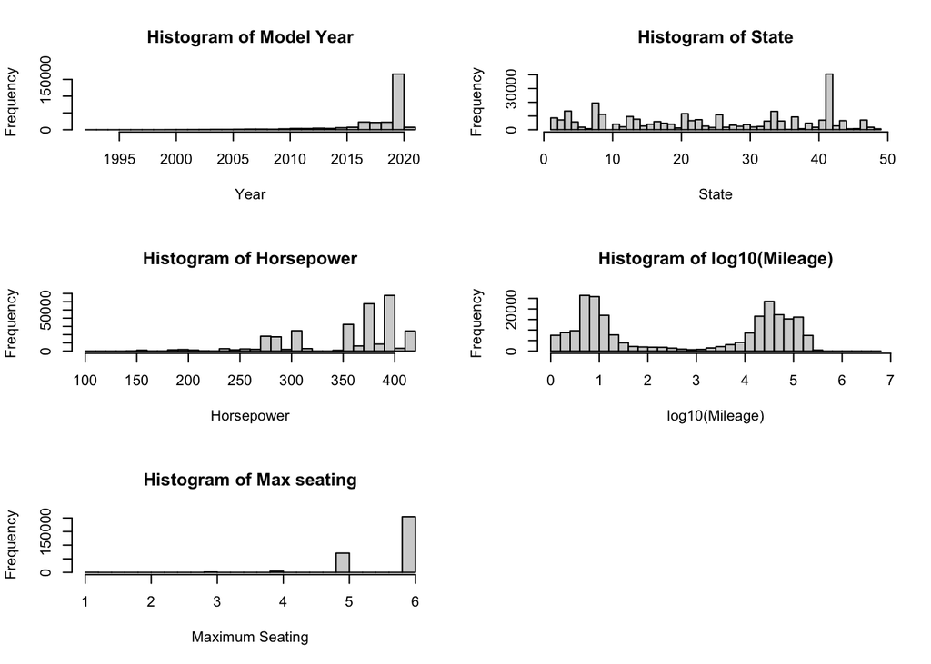

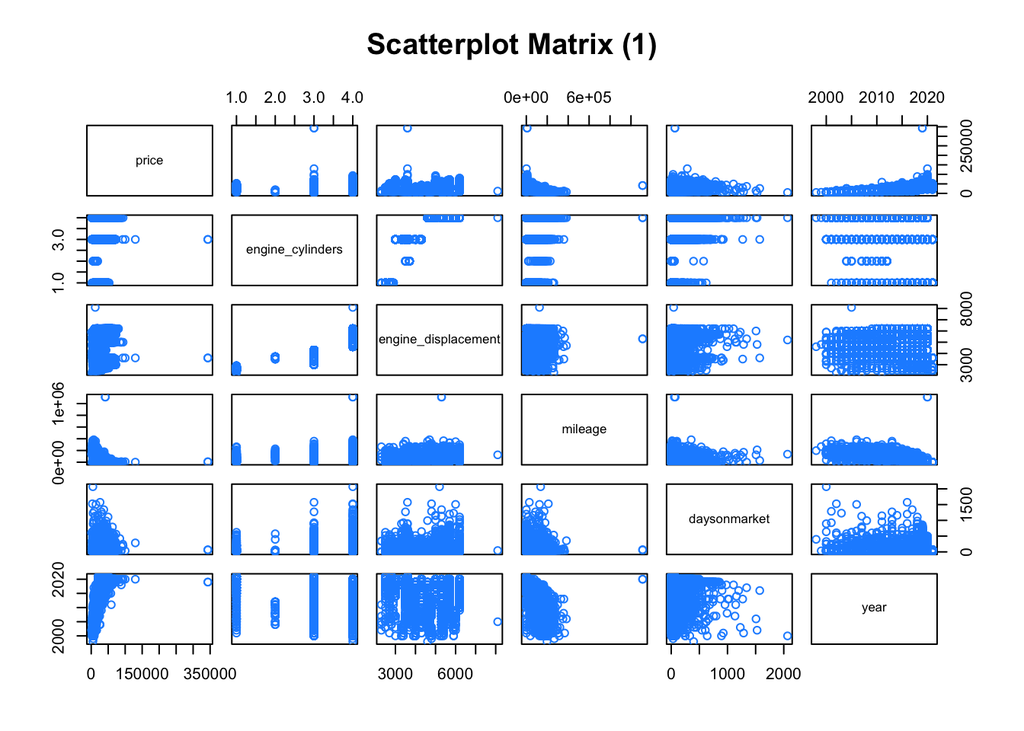

From **Scatterplot Matrix (1)**:

- `price` vs `mileage` appears as if it may benefit if modeled by `1/x`
  - `log(x)` would also work, considering the orders of magnitude
- `engine_cylinders` vs `engine_displacement` are clearly collinear
  - Our model will include `engine_displacement` over `engine_cylinders`
  - This decision is driven by our preference for a `num` variable over a `factor`
- `year` is nearly perfectly linear, as well as (`x + x^2`) quadratic, to our response, `price`
- `daysonmarket` is, to our surprise, not useful and adds lots of noise

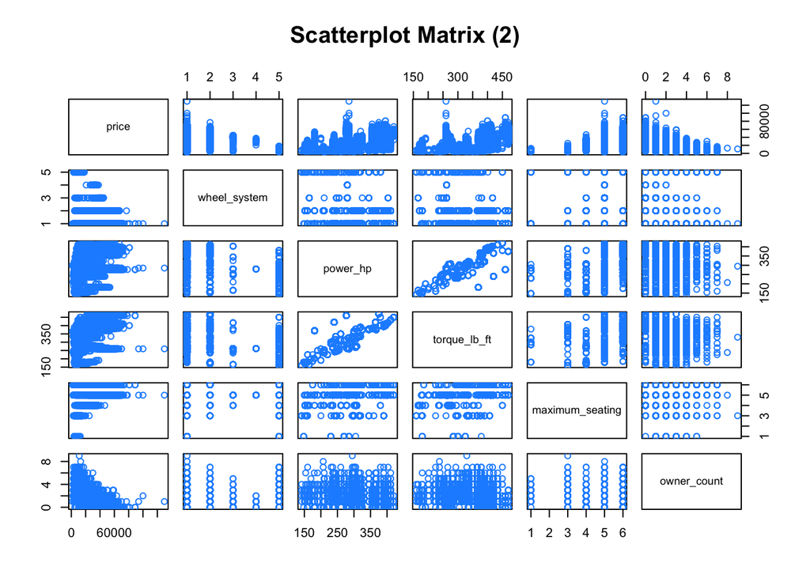

From **Scatterplot Matrix (2)**:

- `power_hp` vs `torque_lb_ft` appear collinear
- `maximum_seating` displays a strong linear relationship with `price`
- `wheel_system` also shows a strong linear relationship with `price`

[figure not shown]

##### Variance Inflation Factors

As a compliment to our `pairs` scatterplot matrices, we examine variance inflation factors (`vif`) to determine which predictors are collinear with 1 or more of the others. The `vif` measures the proportion of the variance within a single predictor that can be explained by a linear combination of the other predictors. A high `vif` (>5) indicates collinearity.

```
##             back_legroom               bed_length        city_fuel_economy
##                1.908e+01                1.559e+01                1.065e+01
##        engine_cylinders6        engine_cylinders8      engine_displacement
##                1.768e+01                4.738e+01                3.371e+01
##             engine_type6             engine_type8       exterior_colorBLUE
##                6.152e+01                5.567e+00                1.803e+01
##        exterior_colorRED     exterior_colorSILVER      exterior_colorWHITE
##                4.652e+01                9.241e+00                1.029e+02
##     franchise_dealerTRUE            front_legroom         fuel_tank_volume
##                1.687e+01                7.154e+02                1.381e+03
##          fuel_typeDiesel                   height     highway_fuel_economy
##                2.796e+03                1.901e+03                2.668e+02
##               horsepower       interior_colorBLUE       interior_colorGRAY
##                2.159e+04                2.969e+01                3.168e+01
##      interior_colorOTHER        interior_colorRED                 latitude
##                8.384e+00                6.713e+01                7.996e+06
##                   length                longitude         maximum_seating3
##                2.809e+06                3.214e+06                1.011e+02
##         maximum_seating6                  mileage              owner_count
##                1.217e+02                5.002e+09                7.795e+02
##            seller_rating            transmissionM          wheel_system4X2
##                5.608e+00                7.208e+00                2.302e+01
##                power_rpm             torque_lb_ft               torque_rpm
##                7.661e+07                3.880e+05                3.995e+08
## regionEast South Central       regionMid Atlantic           regionMountain
##                3.809e+01                4.915e+01                1.873e+01
##        regionNew England            regionPacific     regionSouth Atlantic
##                9.641e+00                1.163e+01                2.097e+01
## regionWest North Central regionWest South Central                  stateAR
##                5.088e+01                7.903e+01                5.657e+00
##                  stateAZ                  stateCA                  stateCO
##                1.462e+01                2.553e+01                5.122e+00
##                  stateDE                  stateFL                  stateGA
##                2.492e+02                1.570e+01                2.314e+01
##                  stateLA                  stateMI                  stateMN
##                1.352e+01                6.536e+00                1.442e+01
##                  stateNC                  stateNE                  stateNH
##                2.043e+01                7.373e+00                5.724e+00
##                  stateNY                  stateOH                  stateOK
##                3.507e+01                3.764e+01                5.108e+00
##                  statePA                  stateTX                  stateVA
##                1.808e+01                5.148e+01                2.480e+01
##                  stateWI
##                1.962e+01
```

**Key Observations**:

- `exterior_color` & `interior_color` look to be poor predictors
  - multiple `exterior_color` values have a high `vif`
- `cylinders`, `engine_type`, `engine_displacement`, `*_fuel_economy`, `horsepower`, `power_rpm` and `torque_lb_ft` all have a high `vif`
- This supports some of our initial assumptions made, when drawing our hypothesis
- `height`, `length`, and `owner_count` each have particularly high `vif`
  - We’d like to better understand with which predictors these are collinear
- Multiple `regions` and `states` have a high `vif`
  - This will become significant, as we seek to build a global prediction model

```r
full_model_no_region_formula = update.formula(
  full_model_formula, ~ . -region -latitude -longitude)
fm1 = lm(full_model_no_region_formula, data = truck_df)
v = vif(fm1)
v[v > 5]
```

```
##         back_legroom           bed_length    city_fuel_economy
##            1.907e+01            1.559e+01            1.065e+01
##    engine_cylinders6    engine_cylinders8  engine_displacement
##            1.768e+01            4.738e+01            3.371e+01
##         engine_type6         engine_type8   exterior_colorBLUE
##            6.152e+01            5.567e+00            1.802e+01
##    exterior_colorRED exterior_colorSILVER  exterior_colorWHITE
##            4.652e+01            9.240e+00            1.029e+02
## franchise_dealerTRUE        front_legroom     fuel_tank_volume
##            1.687e+01            7.153e+02            1.381e+03
##      fuel_typeDiesel               height highway_fuel_economy
##            2.796e+03            1.901e+03            2.667e+02
##           horsepower   interior_colorBLUE   interior_colorGRAY
##            2.159e+04            2.969e+01            3.168e+01
##  interior_colorOTHER    interior_colorRED            isCabTRUE
##            8.383e+00            6.711e+01            1.287e+04
##           is_newTRUE               length     maximum_seating3
##            5.715e+03            2.613e+06            1.011e+02
##     maximum_seating6              mileage          owner_count
##            1.217e+02            4.989e+09            7.794e+02
##        seller_rating        transmissionM      wheel_system4X2
##            5.549e+00            7.208e+00            2.302e+01
##            power_rpm         torque_lb_ft           torque_rpm
##            5.932e+07            2.755e+05            4.610e+07
##              stateAZ              stateCA              stateDE
##            5.038e+00            2.007e+01            2.443e+02
##              stateFL              stateGA              stateLA
##            7.910e+00            7.182e+00            5.578e+00
##              stateMI              stateMN              stateNC
##            6.363e+00            5.211e+00            6.176e+00
##              stateNY              stateOK              statePA
##            2.837e+01            9.798e+00            6.802e+00
##              stateTX
##            6.043e+01
```

```r
# fit with removed state predictor
full_model_no_state_formula = update.formula(full_model_formula, ~ . -state -latitude -longitude)
fm2 = lm(full_model_no_state_formula, data = truck_df)
v = vif(fm2)
v[v > 5]
```

```
##             back_legroom               bed_length        city_fuel_economy
##                1.906e+01                1.557e+01                1.062e+01
##        engine_cylinders6        engine_cylinders8      engine_displacement
##                1.765e+01                4.732e+01                3.368e+01
##             engine_type6             engine_type8       exterior_colorBLUE
##                6.151e+01                5.564e+00                1.802e+01
##        exterior_colorRED     exterior_colorSILVER      exterior_colorWHITE
##                4.648e+01                9.237e+00                1.029e+02
##     franchise_dealerTRUE            front_legroom         fuel_tank_volume
##                1.686e+01                7.143e+02                1.379e+03
##          fuel_typeDiesel                   height     highway_fuel_economy
##                2.796e+03                1.899e+03                2.665e+02
##               horsepower       interior_colorBLUE       interior_colorGRAY
##                2.150e+04                2.968e+01                3.163e+01
##      interior_colorOTHER        interior_colorRED                isCabTRUE
##                8.364e+00                6.711e+01                1.286e+04
##               is_newTRUE                   length         maximum_seating3
##                5.711e+03                2.611e+06                1.010e+02
##         maximum_seating6                  mileage              owner_count
##                1.215e+02                4.921e+09                7.793e+02
##            seller_rating            transmissionM          wheel_system4X2
##                5.148e+00                7.202e+00                2.288e+01
##                power_rpm             torque_lb_ft               torque_rpm
##                8.921e+06                6.146e+04                1.129e+07
## regionWest South Central
##                1.378e+01
```

We found it safe to conclude that `state` is collinear with `region`, and that individual factors within the `state` variable are collinear with each other.

##### Outlier Removal

Next, we attempt to identify the outliers in our data (observations which do not fit the model well). In our analysis, we look at these observations to measure their respective leverages and influence on our model’s predictors. We expect that these observations will have large residuals.

```r
# create formula for simplified additive model omitting character data types
columns_of_interest = setdiff(no_char_columns, c("latitude", "longitude"))
no_char_additive_formula = formula(paste("price ~", paste("", columns_of_interest, sep = " ", collapse = " +")))
outlier_fit_add = lm(no_char_additive_formula, data = truck_df)
print_useful_summary_stats(outlier_fit_add)
```

```
##    resid_std_err        r.squared fstatistic.value    p.value.value
##        5222.4889           0.8298       11814.5860           0.0000
```

```r
count_gt_stddev = c(length(which(rstandard(outlier_fit_add) > 1)),
  length(which(rstandard(outlier_fit_add) > 2)),
  length(which(rstandard(outlier_fit_add) > 3)),
  length(which(rstandard(outlier_fit_add) > 4)))
number_of_stddevs = c(1,2,3,4)
model_results = data.frame(number_of_stddevs, count_gt_stddev)
colnames(model_results) = c("# of stddev", "Count of rows > stddev")
knitr::kable(model_results)
```

| # of stddev | Count of rows > stddev |
| --- | --- |
| 1 | 40410 |
| 2 | 7976 |
| 3 | 1238 |
| 4 | 276 |

```r
# cooks.distance tests (intersection of high-outlier, high-influence is 95%)
# outliers flagged for removal
high_influence_rows = which(cooks.distance(outlier_fit_add) > 4 / length(outlier_fit_add$residuals))
length(high_influence_rows)
```

```
## [1] 12231
```

```r
intersection_of_high_inf_high_outlier = intersect(
  which(rstandard(outlier_fit_add) > 3), high_influence_rows)
(pct = length(intersection_of_high_inf_high_outlier) / count_gt_stddev[3] * 100)
```

```
## [1] 86.91
```

```r
intersection_of_high_inf_high_outlier = intersect(
  which(rstandard(outlier_fit_add) > 4), high_influence_rows)
(pct = length(intersection_of_high_inf_high_outlier) / count_gt_stddev[4] * 100)
```

```
## [1] 100
```

```r
# analyze outlier rows to check for commonality
outlier_rows_to_remove = intersection_of_high_inf_high_outlier
outlier_df = truck_df[outlier_rows_to_remove,]
```

- **1238** rows **> 3** standard deviations from the mean
- **276** rows **> 4** standard deviations from the mean

A significant percentage (`100%`) of observations with large-residuals also have high leverage and, therefore, have high influence. These observations are good candidates for exclusion from our dataset.

```r
# analyze outlier observations to see if there are commonalities in their data
outlier_rows_to_remove = intersection_of_high_inf_high_outlier
outlier_df = truck_df[outlier_rows_to_remove,]

# extraordinarily large number of Jeep Gladiators found in the outliers
nrow(outlier_df[outlier_df[,"model_name"] == c("gladiator", "Gladiator"), ]) /
    nrow(outlier_df) * 100
```

```
## [1] 10.14
```

```r
# several Ford F150 as well
nrow(outlier_df[outlier_df[,"model_name"] == c("F-150", "F150"), ]) /
    nrow(outlier_df) * 100
```

```
## [1] 15.58
```

```r
# a notably high count of 4x4 trucks
nrow(outlier_df[outlier_df[,"wheel_system"] == c("4WD"), ]) /
    nrow(outlier_df) * 100
```

```
## [1] 83.7
```

##### Examples of Clear Outliers Within Predictor Distributions

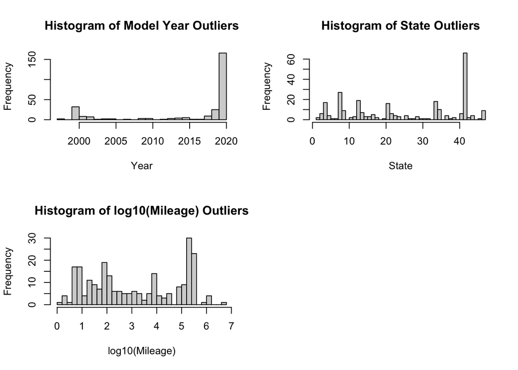

```r
par(mfrow=c(2,2))

hist(outlier_df$year, breaks=length(unique(outlier_df$year)),
     xlab="Year", ylab = "Frequency", main = "Histogram of Model Year Outliers")
hist(as.integer(outlier_df$state), breaks=length(unique(outlier_df$state)),
     xlab="State", ylab = "Frequency", main = "Histogram of State Outliers")
hist(log10(outlier_df$mileage), breaks=30,
     xlab="log10(Mileage)", ylab = "Frequency", main = "Histogram of log10(Mileage) Outliers")
```

We continue our exploration by refitting the “full” model with outliers removed based on their being influential (measured by `rstandard` and `cooks.distance`). Reviewing the affect of the outlier removal on the model’s coefficients, helps us confirm whether or not there is significant influence from these observations.

```r
# refitted full model with outliers removed
no_outlier_fit_add = lm(no_char_additive_formula, data = truck_df[-outlier_rows_to_remove,])
# summary(no_outlier_fit_add)
print_useful_summary_stats(no_outlier_fit_add)
```

```
##    resid_std_err        r.squared fstatistic.value    p.value.value
##          5036.32             0.84         12709.89             0.00
```

```r
# percentage change in model coefficients
pct_chng_in_model_coeff = abs(
  (coef(no_outlier_fit_add) - coef(outlier_fit_add))
  / coef(no_outlier_fit_add)) * 100

# check for coefficients with a > 10% change
pct_chng_in_model_coeff[pct_chng_in_model_coeff > 10.0]
```

```
##              (Intercept)          cabinNot Listed         cabinRegular Cab
##                    13.74                    12.35                    32.01
##        city_fuel_economy             daysonmarket      engine_displacement
##                    24.16                    85.57                    14.36
##                     <NA>                     <NA>                     <NA>
##                       NA                       NA                       NA
##       exterior_colorGRAY      exterior_colorGREEN        frame_damagedTRUE
##                    47.81                    97.51                    14.10
##        has_accidentsTRUE      interior_colorGREEN      interior_colorOTHER
##                    33.36                    25.13                    11.66
##                   length                  mileage              owner_count
##                    18.53                    18.90                    69.81
##              salvageTRUE          wheel_systemFWD          wheel_systemRWD
##                    12.29                    42.85                    15.00
##                     year                 power_hp                power_rpm
##                    13.56                    14.93                    16.20
##             torque_lb_ft regionWest North Central                  stateAR
##                    13.49                    11.59                    11.73
##                  stateCA                  stateHI                  stateIL
##                    13.81                    26.66                   115.58
##                  stateIN                  stateMA                  stateMO
##                    15.18                    11.68                   409.04
##                  stateND                  stateNM                  stateNV
##                    25.22                   172.52                   134.63
##                  stateOK                     <NA>                  stateSC
##                    11.22                       NA                    18.41
##                     <NA>                  stateTN                     <NA>
##                       NA                    13.07                       NA
##                     <NA>                     <NA>                     <NA>
##                       NA                       NA                       NA
##                     <NA>                     <NA>
##                       NA                       NA
```

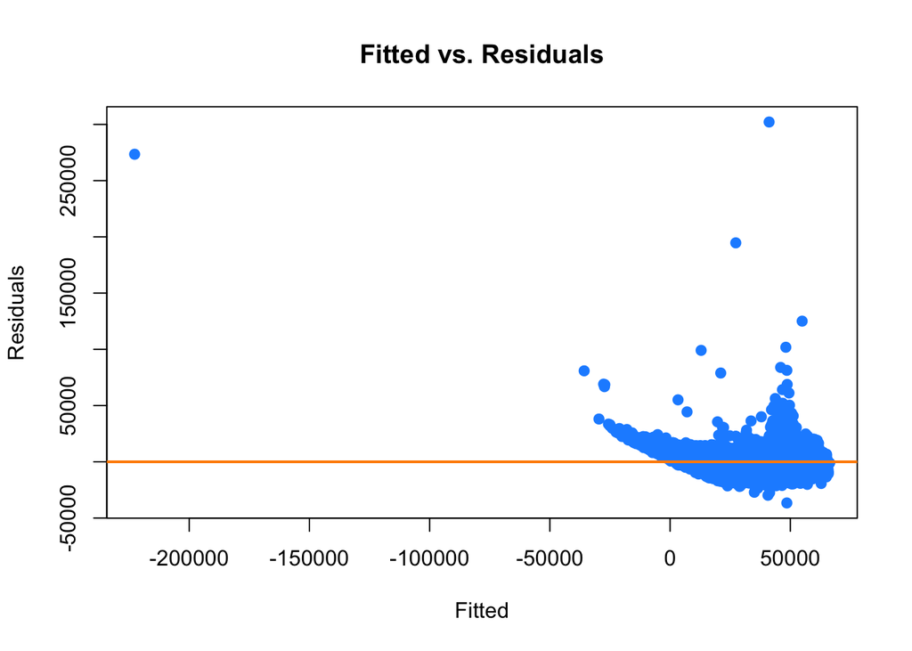

```r
# compare removed outlier models
plot_fitted_resid(outlier_fit_add)
```

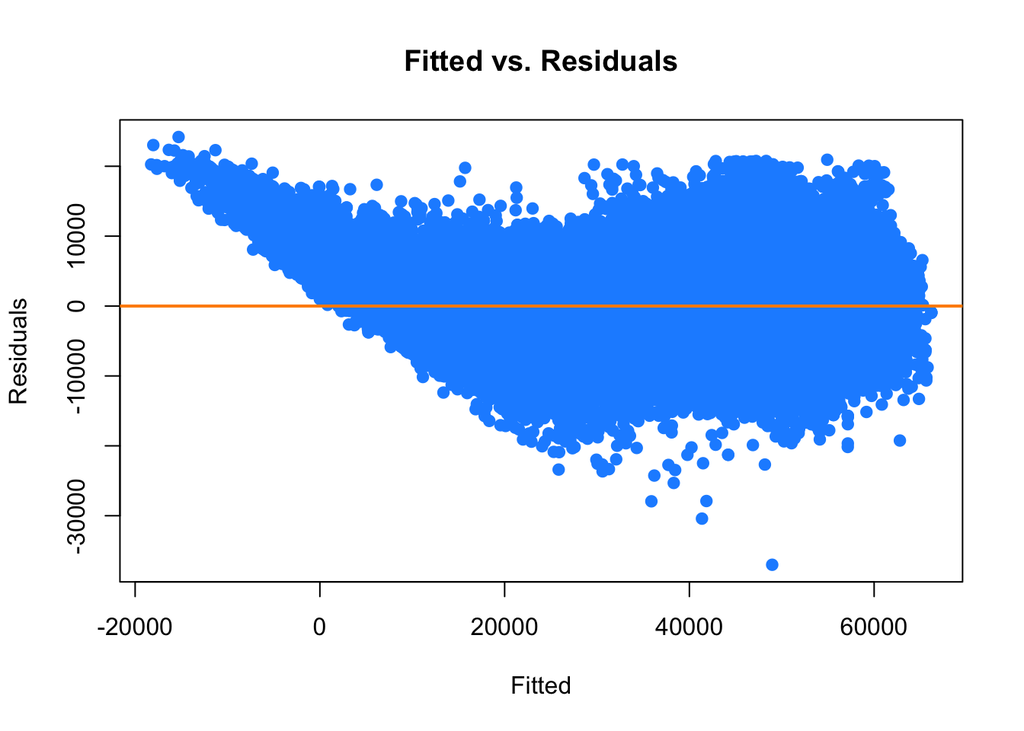

```r
plot_fitted_resid(no_outlier_fit_add)
```

From the above code chunk, we find that the $RMSE$ and $R^2$ values of the model are, mostly, unaffected by the removal of outlier observations. There is, however, a large percentage change (~50 - 400%) in some of the model’s coefficients ($\beta$) after refitting. We conclude that this change is rather significant, considering there are only `276 outlier rows > 4 stddev` and `281301` in the dataset.

We now continue our analysis with the influential outliers removed from our dataset (assuming they are user error, and not relevant to our model).

```r
truck_df = truck_df[-outlier_rows_to_remove,]
```

### iii. Regional Model Analysis - Mid Atlantic

As part of our approach to fitting a useful linear model, we decided to parse our dataset by `region`. In doing so, we allowed ourselves the opportunity to not only divide and conquer, but to further determine the efficacy of our analysis by comparing our findings across the regions. This section focuses on our model exploration of the **Mid-Atlantic** (NY, PA, and NJ), but additional analysis can be found in the Appendix.

```r
set.seed(12345)
par(mfrow=c(1,1))

# remove unusable character variables from dataframe
cols_to_keep = append(intersect(no_char_columns, colnames(truck_df)), "price")
truck_df = truck_df[, cols_to_keep]

# test/train split of dataset
trn_idx = sample(nrow(truck_df), nrow(truck_df) * 0.8)
truck_df_trn = truck_df[trn_idx,]
truck_df_tst = truck_df[-trn_idx,]

# process dataset for mid atlantic region analysis
mid_atlantic_data = truck_df_trn[truck_df_trn$region == "Mid Atlantic",]
drops = c("region", "state")
mid_atlantic_data = mid_atlantic_data[ , !(names(mid_atlantic_data) %in% drops)]

# fit mid_atlantic_base_model
base_predictors = c("engine_displacement", "engine_cylinders", "highway_fuel_economy", "horsepower", "maximum_seating", "transmission", "mileage", "year", "wheel_system", "power_hp", "bed_length", "cabin", "salvage", "franchise_dealer" )
base_predictors_formula = formula(paste("price ~", paste("", base_predictors, sep = " ", collapse = " +")))
mid_atlantic_base_model = lm(base_predictors_formula, data = mid_atlantic_data)
print_useful_summary_stats(mid_atlantic_base_model)
```

```
##    resid_std_err        r.squared fstatistic.value    p.value.value
##        6361.0785           0.7536        1960.3536           0.0000
```

```r
# fit mid_atlantic_full_model
mid_atlantic_full_model = lm(price ~ ., data = mid_atlantic_data)
print_useful_summary_stats(mid_atlantic_full_model)
```

```
##    resid_std_err        r.squared fstatistic.value    p.value.value
##        4681.8761           0.8669        1513.7485           0.0000
```

```r
# fit optimized model via backward BIC search
# BIC chosen over AIC in order to favor less predictors in model
nb = length(resid(mid_atlantic_base_model))
base_model_bic = step(mid_atlantic_base_model, direction = "backward", k = log(nb), trace = 0)
summary(base_model_bic)
```

```
##
## Call:
## lm(formula = price ~ engine_displacement + engine_cylinders +
##     horsepower + maximum_seating + mileage + year + wheel_system +
##     power_hp + bed_length + franchise_dealer, data = mid_atlantic_data)
##
## Residuals:
##    Min     1Q Median     3Q    Max
## -20157  -4361   -823   3350  28987
##
## Coefficients:
##                       Estimate Std. Error t value Pr(>|t|)
## (Intercept)          -3.05e+06   7.11e+04  -42.87  < 2e-16 ***
## engine_displacement  -9.59e-01   1.75e-01   -5.48  4.3e-08 ***
## engine_cylinders5     2.56e+03   1.08e+03    2.36    0.018 *
## engine_cylinders6    -8.08e+02   3.91e+02   -2.07    0.039 *
## engine_cylinders8     1.86e+03   6.02e+02    3.09    0.002 **
## horsepower            5.12e+01   1.79e+00   28.53  < 2e-16 ***
## maximum_seating3      9.91e+03   1.67e+03    5.93  3.1e-09 ***
## maximum_seating4      3.67e+03   1.57e+03    2.34    0.019 *
## maximum_seating5      9.03e+03   1.50e+03    6.03  1.7e-09 ***
## maximum_seating6      3.46e+03   1.53e+03    2.27    0.023 *
## mileage              -1.10e-01   2.69e-03  -40.94  < 2e-16 ***
## year                  1.53e+03   3.53e+01   43.16  < 2e-16 ***
## wheel_system4X2      -4.68e+03   4.36e+02  -10.74  < 2e-16 ***
## wheel_systemAWD      -2.74e+03   4.53e+02   -6.05  1.5e-09 ***
## wheel_systemRWD       6.56e+03   7.45e+02    8.80  < 2e-16 ***
## power_hp              2.04e+01   1.31e+00   15.58  < 2e-16 ***
## bed_length           -2.03e+02   9.96e+00  -20.39  < 2e-16 ***
## franchise_dealerTRUE  1.10e+03   1.87e+02    5.86  4.6e-09 ***
## ---
## Signif. codes:  0 '***' 0.001 '**' 0.01 '*' 0.05 '.' 0.1 ' ' 1
##
## Residual standard error: 6370 on 15393 degrees of freedom
## Multiple R-squared:  0.753,  Adjusted R-squared:  0.753
## F-statistic: 2.76e+03 on 17 and 15393 DF,  p-value: <2e-16
```

```r
print_useful_summary_stats(base_model_bic)
```

```
##    resid_std_err        r.squared fstatistic.value    p.value.value
##         6367.214            0.753         2760.072            0.000
```

```r
# add interactions to base model to explore significance
base_predictors = c("engine_displacement",
                    "engine_cylinders",
                    "highway_fuel_economy",
                    "horsepower",
                    "maximum_seating",
                    "transmission",
                    "mileage",
                    "year",
                    "wheel_system",
                    "power_hp",
                    "bed_length",
                    "cabin",
                    "salvage",
                    "franchise_dealer")
base_interactions = combn(base_predictors, 2, FUN = paste, collapse = ":")
base_interactions_predictors = c(base_predictors, base_interactions)
base_predictors_formula = formula(paste("price ~", paste("", base_interactions_predictors, sep = " ", collapse = " +")))
mid_atlantic_int_model = lm(base_predictors_formula, data = mid_atlantic_data)
print_useful_summary_stats(mid_atlantic_int_model)
```

```
##    resid_std_err        r.squared fstatistic.value    p.value.value
##        4769.3435           0.8634         408.0334           0.0000
```

```r
# refit model with identified significant interactions using the predictors' p-values
significant_int_predictors = c("year:bed_length",
                               "year:mileage",
                               "maximum_seating:bed_length",
                               "engine_cylinders:highway_fuel_economy",
                               "engine_cylinders:horsepower",
                               "engine_displacement:engine_cylinders",
                               "engine_displacement:highway_fuel_economy")
improved_interactions_predictors = c(base_predictors, significant_int_predictors)
base_predictors_formula = formula(paste("price ~", paste("", improved_interactions_predictors, sep = " ", collapse = " +")))
improved_mid_atlantic_int_model = lm(base_predictors_formula, data = mid_atlantic_data)
print_useful_summary_stats(improved_mid_atlantic_int_model)
```

```
##    resid_std_err        r.squared fstatistic.value    p.value.value
##        5507.3755           0.8155        1741.5316           0.0000
```

Seen in the above chunk, we concluded that adding two-way interaction terms is notably significant and makes valubale improvements to our model. After looking over the predictors’ p-values, we refit the base model, including only the most significant interaction terms in order to maintain the least number of variables.

### iv. Significant Variable Transformations and Interactions

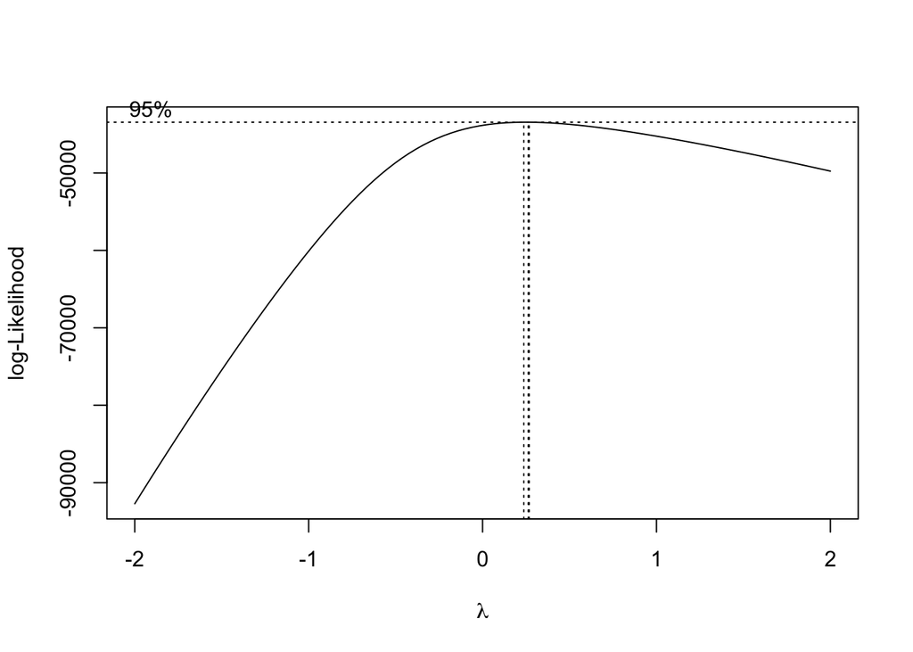

```r
boxcox(improved_mid_atlantic_int_model, plotit = TRUE)
```

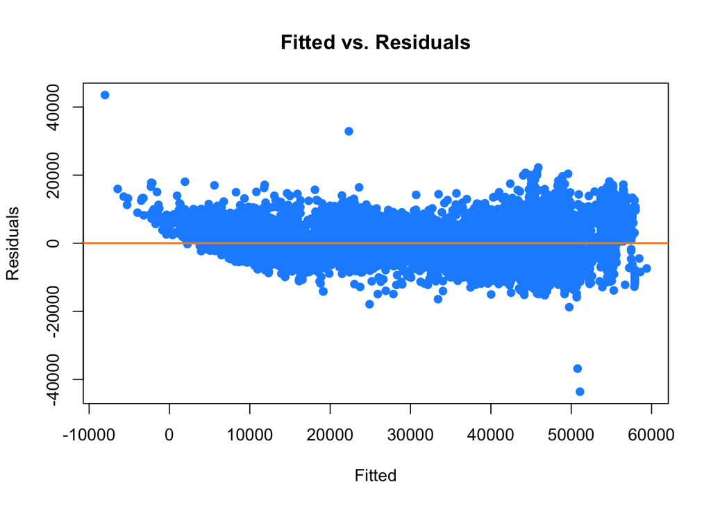

```r
# fitted vs residuals and QQ plots for improved_mid_atlantic_int_model
plot_fitted_resid(improved_mid_atlantic_int_model)
```

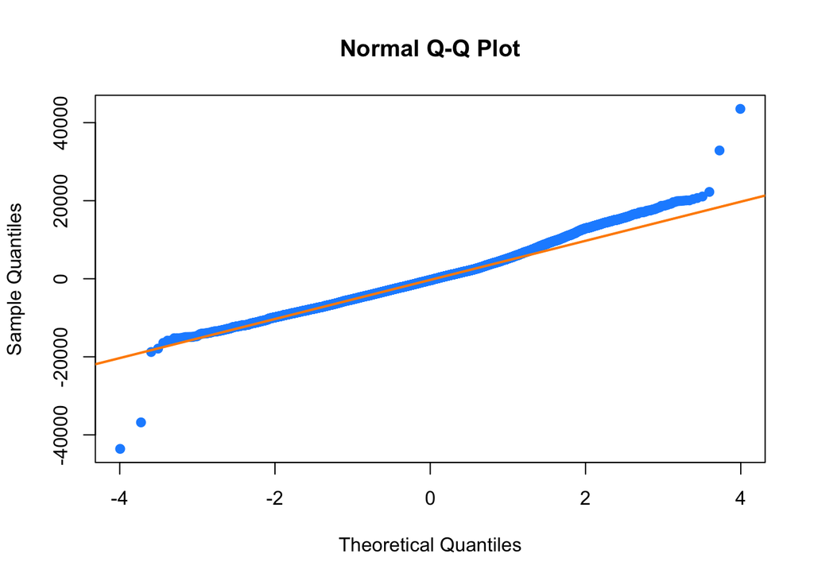

```r
plot_qq(improved_mid_atlantic_int_model)
```

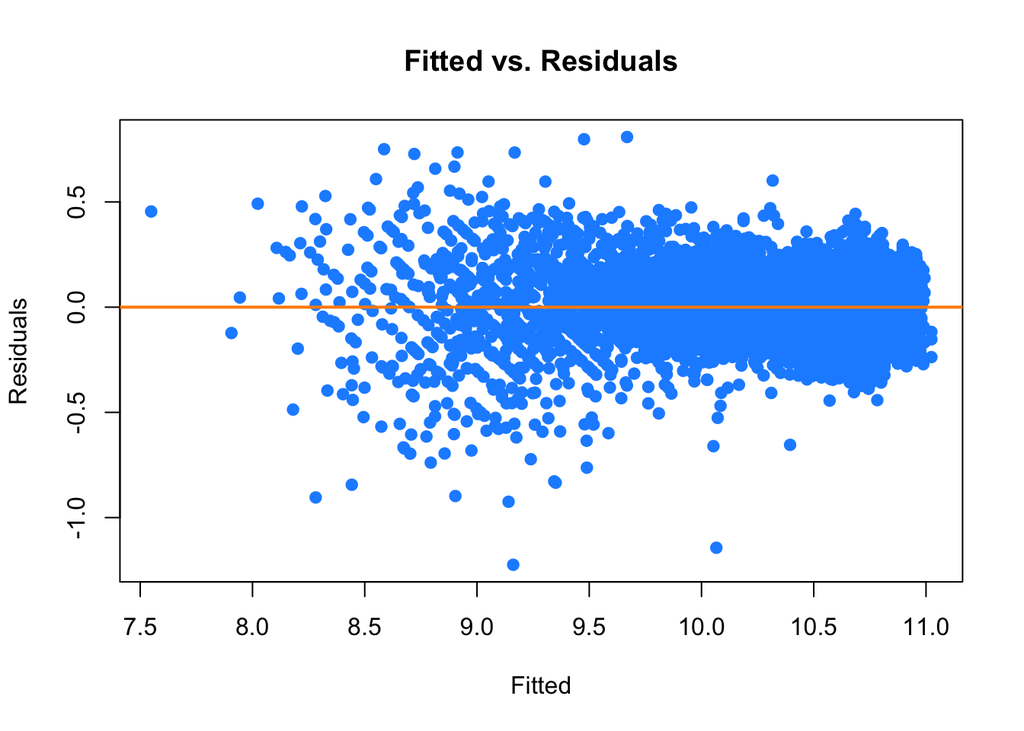

```r
# refit log-transformed response model
base_predictors_formula = formula(paste("log(price) ~", paste("", improved_interactions_predictors, sep = " ", collapse = " +")))
log_mid_atlantic_int_model = lm(base_predictors_formula, data = mid_atlantic_data)
print_useful_summary_stats(log_mid_atlantic_int_model)
# fitted vs residuals plot for log_mid_atlantic_int_model
plot_fitted_resid(log_mid_atlantic_int_model)
```

[output not shown]

From the Box-Cox analysis, log-likelihood reaches a maximum when $\lambda$ is between `0` and `0.5`. Therefore, we choose to have a log transformation on our response variable, `price`.

Comparing the **fitted vs residuals** plots from before and after the applied log-transformation of the response variable, along with our analysis of the results from the log model, we see very significant improvements.

At this point, we have arrived on a well-fitted `price` prediction regional model for the used truck dataset. For us to achieve an equally effective global model for all US data, we require further ANOVA testing. This exploration will determine the significance of including `region` as a model predictor.

```r
# use regional model to fit a global model to all us data (not including region as a predictor)
base_predictors_formula = formula(paste("log(price) ~", paste("", improved_interactions_predictors, sep = " ", collapse = " +")))
global_model = lm(base_predictors_formula, data = truck_df_trn)
print_useful_summary_stats(global_model)
```

```
##    resid_std_err        r.squared fstatistic.value    p.value.value
##           0.1464           0.8805       40387.9614           0.0000
```

```r
# ANOVA test global model with region vs without region as a predictor
add_region = c(improved_interactions_predictors, "region")
formula = formula(paste("log(price) ~", paste("", add_region, sep = " ", collapse = " +")))
global_model_add_region = lm(formula, data = truck_df_trn)
print_useful_summary_stats(global_model_add_region)
```

```
##    resid_std_err        r.squared fstatistic.value    p.value.value
##           0.1447           0.8834       34743.8496           0.0000
```

```r
anova(global_model, global_model_add_region)["Pr(>F)"]
```

```
##   Pr(>F)
## 1
## 2 <2e-16 ***
## ---
## Signif. codes:  0 '***' 0.001 '**' 0.01 '*' 0.05 '.' 0.1 ' ' 1
```

```r
# diagnostics for global model
rmse_trn = sqrt(mean((truck_df_trn$price - predict(global_model, truck_df_trn)) ^ 2))
rmse_tst = sqrt(mean((truck_df_tst$price - predict(global_model, truck_df_tst)) ^ 2))

# diagnostics for global model with region
(rmse_trn = sqrt(mean((truck_df_trn$price - predict(global_model_add_region, truck_df_trn)) ^ 2)))
```

```
## [1] 42057
```

```r
(rmse_tst = sqrt(mean((truck_df_tst$price - predict(global_model_add_region, truck_df_tst)) ^ 2)))
```

```
## [1] 42018
```

## Results

##### Model Comparison

| Model | $(p - 1)$ | RMSE | $R^2$ | BP Test | Shapiro-Wilk Test |
| --- | --- | --- | --- | --- | --- |
| **Base Model** | 24 | 6355.9169 | 0.7536 | Reject $H_0$ | Reject $H_0$ |
| **Full Model** | 69 | 4671.6877 | 0.8669 | Reject $H_0$ | Reject $H_0$ |
| **Base BIC Model** | 17 | 6363.4945 | 0.753 | Reject $H_0$ | Reject $H_0$ |
| **Base Interaction Model** | 282 | 4732.6843 | 0.8634 | Reject $H_0$ | Reject $H_0$ |
| **Improved Interaction Model** | 40 | 5500.2235 | 0.8155 | Reject $H_0$ | Reject $H_0$ |
| **Log Transform Model** | 40 | 0.1386 | 0.905 | Reject $H_0$ | Reject $H_0$ |

From the above table, it quickly becomes clear why we have chosen the `log` response model as our final prediction model.

Starting with the base model, a $R^2$ of 0.7536 is among the lowest that we found across all of our linear models. This comes as no surprise, however, given we started with a simple and “naive” approach.

Similarly unsurprising, when analyzing the full model, we came across a much higher $R^2$ and a favorable RMSE. Unfortunately, as expected with full, exhaustive models, the number of predictors has become quite large, making the full model complex and not an ideal model for interpretation.

After applying a backward search, leveraging BIC to penalize against keeping predictors from our base model, we find ourselves with a model that is the easiest to interpret. Unfortunately, as much as we seek to simplify our models in linear regression, we are focusing on the strength of our models as predictors. Our backwards BIC selected model sacrifices prediction power, as seen by the $R^2$ and RMSE decreasing and increasing respectively. In the end, we’re left with results that are not far off from our initial “naive” base model.

As a result of our findings across the base, full, and backwards BIC models, we decided to introduce model interactions. In our base interaction model, we make use of all significant predictors along with all two-way interactions between them. In doing so, we found some improvements to the $R^2$ and RMSE. In fact, they wound up very close to the full additive model. Alas, as we found with the full additive model, the number of predictors becomes painfully extraordinarily large relative to the other models, making the base interaction model both complex and difficult to interpret.

Before arriving at our `log` response model, we sought to improve the base interaction model by highlighting its most significant interactions. These interactions were selected through evaluating their `p-values` using `t` tests. This approach resulted in a significant decrease in the number of predictors at 40 and a decent return in $R^2$ and RMSE. The improved interaction model boasts being relatively less complex and easier to interpret, when compared to its predecessor. And, although it provides results that may be adequate, we ultimately decided to explore the transformation of the response as a final model improvement.

##### Model Prediction

| Model | Mean Prediction Error | Prediction Error Standard Deviation |
| --- | --- | --- |
| **Base Model** | -663.6451 | 6685.8354 |
| **Full Model** | -2059.0244 | 6428.5499 |
| **Base BIC Model** | -630.977 | 6692.9161 |
| **Base Interaction Model** | 218.5025 | 5768.629 |
| **Improved Interaction Model** | 96.2006 | 6141.3369 |
| **Log Transform Model** | -654.8949 | 5623.9829 |

##### Base Model

```r
format(names(coef(mid_atlantic_base_model)[-1]), fill = getOption("width"))
```

```
##  [1] "engine_displacement " "engine_cylinders5   " "engine_cylinders6   "
##  [4] "engine_cylinders8   " "highway_fuel_economy" "horsepower          "
##  [7] "maximum_seating3    " "maximum_seating4    " "maximum_seating5    "
## [10] "maximum_seating6    " "transmissionM       " "mileage             "
## [13] "year                " "wheel_system4X2     " "wheel_systemAWD     "
## [16] "wheel_systemRWD     " "power_hp            " "bed_length          "
## [19] "cabinExtended Cab   " "cabinLarge Crew Cab " "cabinNot Listed     "
## [22] "cabinRegular Cab    " "salvageTRUE         " "franchise_dealerTRUE"
```

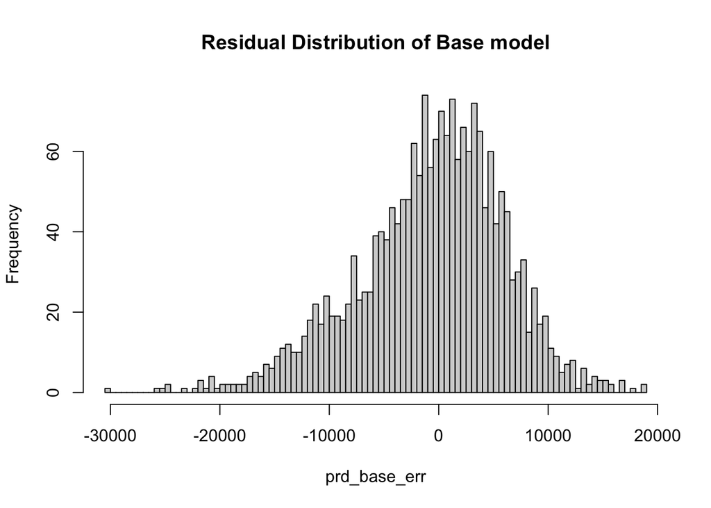

```r
hist(prd_base_err, breaks = 100, main = "Residual Distribution of Base model")
```

##### Full Model

```r
format(names(coef(mid_atlantic_full_model)[-1]), fill = getOption("width"))
```

```
##  [1] "back_legroom              " "bed_length                "
##  [3] "cabinExtended Cab         " "cabinLarge Crew Cab       "
##  [5] "cabinNot Listed           " "cabinRegular Cab          "
##  [7] "city_fuel_economy         " "daysonmarket              "
##  [9] "engine_cylinders5         " "engine_cylinders6         "
## [11] "engine_cylinders8         " "engine_displacement       "
## [13] "engine_type5              " "engine_type6              "
## [15] "engine_type8              " "exterior_colorBLUE        "
## [17] "exterior_colorBROWN       " "exterior_colorGRAY        "
## [19] "exterior_colorGREEN       " "exterior_colorOTHER       "
## [21] "exterior_colorRED         " "exterior_colorSILVER      "
## [23] "exterior_colorWHITE       " "exterior_colorYELLOW      "
## [25] "fleetTRUE                 " "frame_damagedTRUE         "
## [27] "franchise_dealerTRUE      " "front_legroom             "
## [29] "fuel_tank_volume          " "fuel_typeDiesel           "
```

[output cut: 20 more lines]

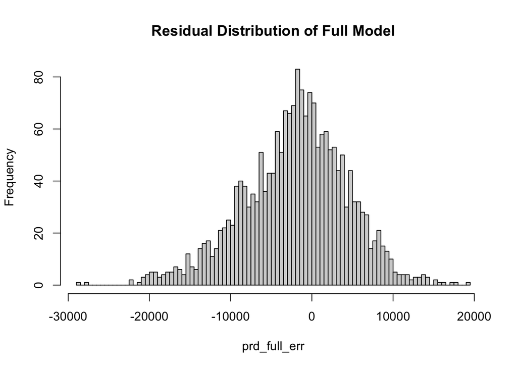

```r
hist(prd_full_err, breaks = 100, main = "Residual Distribution of Full Model")
```

##### Improved Interaction Model

```r
format(names(coef(improved_mid_atlantic_int_model)[-1]), fill = getOption("width"))
```

```
##  [1] "engine_displacement                     "
##  [2] "engine_cylinders5                       "
##  [3] "engine_cylinders6                       "
##  [4] "engine_cylinders8                       "
##  [5] "highway_fuel_economy                    "
##  [6] "horsepower                              "
##  [7] "maximum_seating3                        "
##  [8] "maximum_seating4                        "
##  [9] "maximum_seating5                        "
## [10] "maximum_seating6                        "
## [11] "transmissionM                           "
## [12] "mileage                                 "
## [13] "year                                    "
## [14] "wheel_system4X2                         "
## [15] "wheel_systemAWD                         "
```

[output cut: 25 more lines]

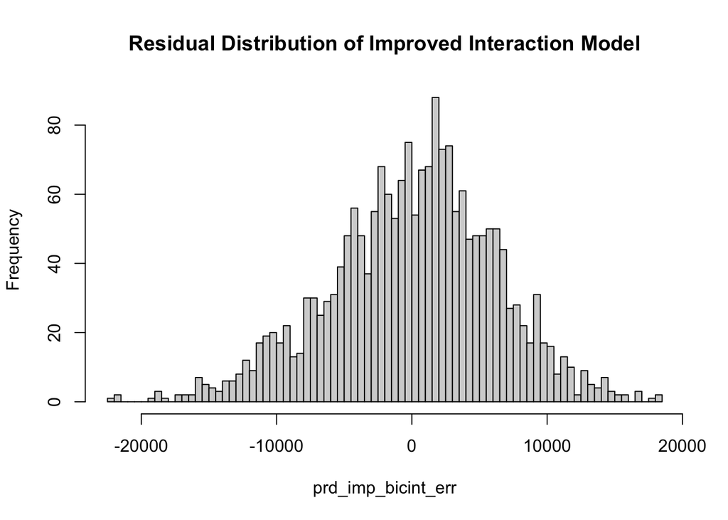

```r
hist(prd_imp_bicint_err, breaks = 100, main = "Residual Distribution of Improved Interaction Model")
```

##### Finalized Global Model (Log Transform)

```r
format(names(coef(log_mid_atlantic_int_model)[-1]), fill = getOption("width"))
```

```
##  [1] "engine_displacement                     "
##  [2] "engine_cylinders5                       "
##  [3] "engine_cylinders6                       "
##  [4] "engine_cylinders8                       "
##  [5] "highway_fuel_economy                    "
##  [6] "horsepower                              "
##  [7] "maximum_seating3                        "
##  [8] "maximum_seating4                        "
##  [9] "maximum_seating5                        "
## [10] "maximum_seating6                        "
## [11] "transmissionM                           "
## [12] "mileage                                 "
## [13] "year                                    "
## [14] "wheel_system4X2                         "
## [15] "wheel_systemAWD                         "
```

[output cut: 25 more lines]

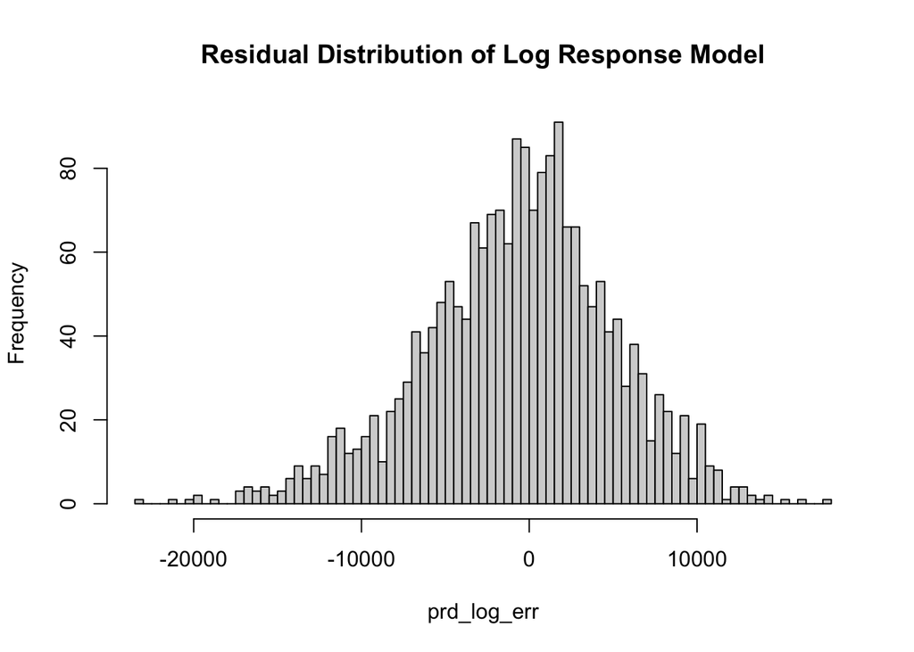

```r
hist(prd_log_err, breaks = 100, main = "Residual Distribution of Log Response Model")
```

##### Fitted vs Residual & QQ Plots

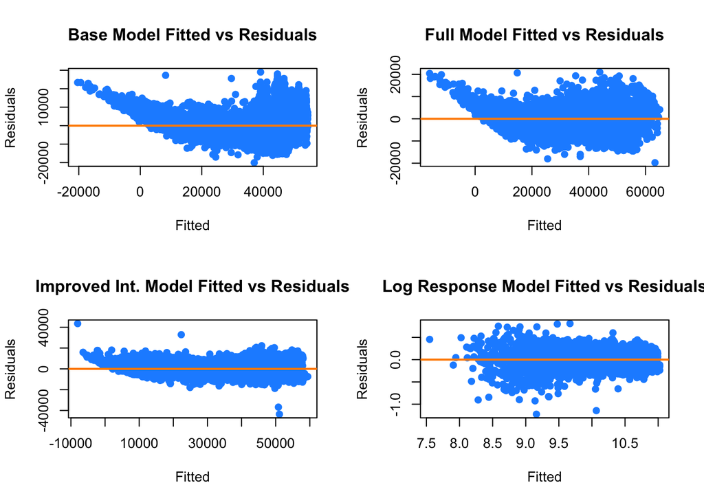

```r
par(mfrow=c(2,2))

plot_fitted_resid(mid_atlantic_base_model, main = "Base Model Fitted vs Residuals")
plot_fitted_resid(mid_atlantic_full_model, main = "Full Model Fitted vs Residuals")
plot_fitted_resid(improved_mid_atlantic_int_model, main = "Improved Int. Model Fitted vs Residuals")
plot_fitted_resid(log_mid_atlantic_int_model, main = "Log Response Model Fitted vs Residuals")
```

*Base Model (top-left), Full Model (top-right), Improved Interaction Model (bottom-left), Log Response Model (bottom-right)*

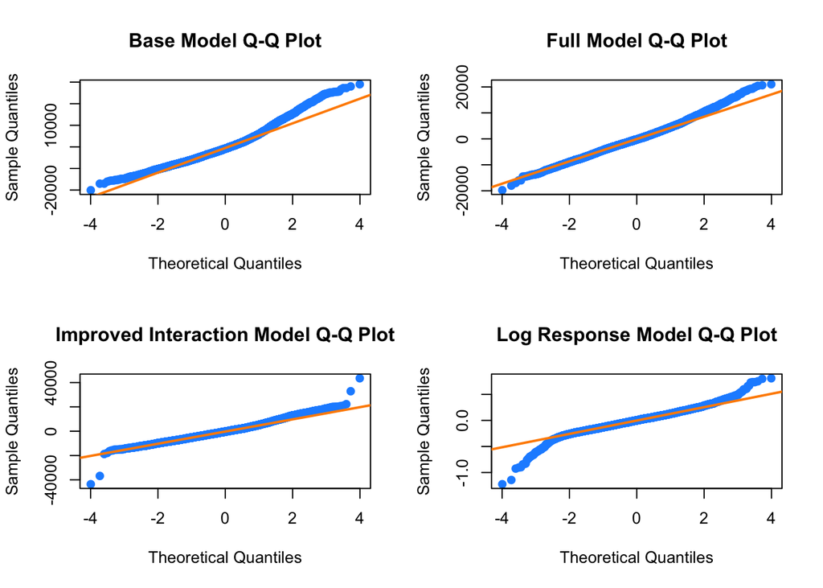

```r
par(mfrow=c(2,2))

plot_qq(mid_atlantic_base_model, main = "Base Model Q-Q Plot")
plot_qq(mid_atlantic_full_model, main = "Full Model Q-Q Plot")
plot_qq(improved_mid_atlantic_int_model, main = "Improved Interaction Model Q-Q Plot")
plot_qq(log_mid_atlantic_int_model, main = "Log Response Model Q-Q Plot")
```

*Base Model (top-left), Full Model (top-right), Improved Interaction Model (bottom-left), Log Response Model (bottom-right)*

## Discussion

As previously demonstrated in the Results section, the diagnostic analysis of each of our models failed to support the **LINE** assumptions of linear regression. More specifically, the assumptions of error (residuals) normality and constant variance.

The null hypotheses, for each of the Breusch-Pagan tests we conducted for constant variance, were all rejected. The same is true for each Shapiro-Wilk test performed, thereby indicating that the “normal distribution” of our models’ residuals is suspect. As noted in our class lectures, these tests are not 100% accurate, but definitely raise questions about our dataset, suggesting that it may not be “ideal” (or in an optimal state) per **LINE** criteria. Nonetheless, we choose to not write off our efforts, as our model may be “close enough” to be statistically useful.

Had we had the time, we believe some additional effort could have been made to refine the accuracy of the model(s) on the full US dataset. It would seem reasonable to assume that using a larger dataset would likely expose our model(s) to larger sets of outlier observations with potentially unusual or invalid data. Additionally, we did point out that `region` and `state` were both identified as significant predictors from the start of our analysis. Predictors that have proven to be difficult to model. `state` and `region` have a high probability of being collinear, but may not necessarily be collinear, depending on the region(s) and state(s) in question.

Some further analysis regarding which states are truly/particularly significant and which are collinear may have allowed us the ability to better process our dataset. One idea we had considered was clustering states into more granular regions, which may have potentially improved our RMSE, error normality, and constant variance assumptions.

We also considered linking our geographic information, (e.g. - `latitude`, `longitude`, `zip_code`, `state`, etc.) with other datasets (e.g. - demographic, financial) to aid in uncovering some useful interactions between variables such as `income`, `age`, or `climate`. We believe that such an approach would have also led to improvements of our models’ performance. That said, we chose not to overburden ourselves with the “nice-to-haves”, given our time constraint. In the end, however, we suspect, due to the differences we observed between our regional and global models, that a greater focus on geography could have helped to improve our prediction results.

## Appendix

### i. Data Cleaning

Using the following code, the dataset downloaded from [Kaggle](https://www.kaggle.com/ananaymital/us-used-cars-dataset) is imported and processed through a series of functions which normalize fields, remove useless variables, and set the data structures within the dataset (numeric, factor, etc.).

```r
# fix colors function
fix_colors = function(dataset) {
  colors = c('gray', 'black', 'white', 'green', 'blue', 'red', 'silver', 'yellow', 'brown')

  for (i in 1:length(colors)) {
    dataset[grep(colors[i], dataset, fixed = TRUE)] = colors[i]
  }

  dataset = ifelse(dataset %in% colors, dataset, 'other')
  toupper(dataset)
}

clean_dataset = function() {
  # fix empty and NA entries
  dataset$back_legroom = ifelse(is.na(dataset$back_legroom), 0, dataset$back_legroom)
  dataset$bed = ifelse(is.na(dataset$bed), 'Not Listed', dataset$bed)
  dataset$bed_length = ifelse(is.na(dataset$bed_length), 0, dataset$bed_length)
  dataset$cabin = ifelse(is.na(dataset$cabin), 'Not Listed', dataset$cabin)
  dataset$fleet = ifelse(is.na(dataset$fleet), FALSE, dataset$fleet)
  dataset$frame_damaged = ifelse(is.na(dataset$frame_damaged), FALSE, dataset$frame_damaged)
  dataset$front_legroom = ifelse(is.na(dataset$front_legroom), 0, dataset$front_legroom)
  dataset$fuel_tank_volume = ifelse(is.na(dataset$fuel_tank_volume), 0, dataset$fuel_tank_volume)
  dataset$isCab = ifelse(is.na(dataset$isCab), FALSE, dataset$isCab)
  dataset$has_accidents = ifelse(is.na(dataset$has_accidents), FALSE, dataset$has_accidents)
  dataset$height = ifelse(is.na(dataset$height), 0, dataset$height)
  dataset$highway_fuel_economy = ifelse(is.na(dataset$highway_fuel_economy), 0, dataset$highway_fuel_economy)
  dataset$horsepower = ifelse(is.na(dataset$horsepower), 0, dataset$horsepower)
  dataset$isCab = ifelse(is.na(dataset$isCab), FALSE, dataset$isCab)
  dataset$is_new = ifelse(is.na(dataset$is_new), FALSE, dataset$is_new)
  dataset$length = ifelse(is.na(dataset$length), 0, dataset$length)
  dataset$maximum_seating = ifelse(is.na(dataset$maximum_seating), 0, dataset$maximum_seating)
  dataset$mileage = ifelse(is.na(dataset$mileage), 0, dataset$mileage)
  dataset$owner_count = ifelse(is.na(dataset$owner_count), 0, dataset$owner_count)
  dataset$salvage = ifelse(is.na(dataset$salvage), FALSE, dataset$salvage)
  dataset$seller_rating = ifelse(is.na(dataset$seller_rating), 0, dataset$seller_rating)
  dataset$theft_title = ifelse(is.na(dataset$theft_title), FALSE, dataset$theft_title)
  dataset$transmission = ifelse(dataset$transmission == 'CVT' | dataset$transmission == 'Dual Clutch', 'A', dataset$transmission)
  dataset$wheelbase = ifelse(is.na(dataset$wheelbase), 0, dataset$wheelbase)
  dataset$width = ifelse(is.na(dataset$width), 0, dataset$width)

  # normalize colors
  dataset$exterior_color = tolower(dataset$exterior_color)
  dataset$exterior_color = fix_colors(dataset$exterior_color)
  dataset$interior_color = tolower(dataset$interior_color)
  dataset$interior_color = fix_colors(dataset$interior_color)
  dataset$listing_color = tolower(dataset$listing_color)
  dataset$listing_color = fix_colors(dataset$listing_color)

  # remove any remaining NA entries
  dataset = subset(dataset, !is.na(back_legroom))
  dataset = subset(dataset, back_legroom != '--')
  dataset = subset(dataset, !is.na(bed))
  dataset = subset(dataset, bed_length != '--')
  dataset = subset(dataset, !is.na(cabin))
  dataset = subset(dataset, !is.na(city_fuel_economy))
  dataset = subset(dataset, !is.na(engine_cylinders))
  dataset = subset(dataset, !is.na(engine_type))
  dataset = subset(dataset, !is.na(fuel_type))
  dataset = subset(dataset, !is.na(power))
  dataset = subset(dataset, !is.na(torque))
  dataset = subset(dataset, !is.na(transmission))

  # clean up character data (optimized)
  reg_num = "[:digit:]+.?[:digit:]?"
  reg_rpm = "[:digit:],[:digit:]+"

  dataset$back_legroom = str_extract(dataset$back_legroom, reg_num)
  dataset$bed_length = str_extract(dataset$bed_length, reg_num)
  dataset$front_legroom = str_extract(dataset$front_legroom, reg_num)
  dataset$fuel_tank_volume = str_extract(dataset$fuel_tank_volume, reg_num)
  dataset$engine_cylinders = str_extract(dataset$engine_cylinders, reg_num)
  dataset$engine_type = str_extract(dataset$engine_type, reg_num)
  dataset$height = str_extract(dataset$height, reg_num)
  dataset$length = str_extract(dataset$length, reg_num)
  dataset$maximum_seating = str_extract(dataset$maximum_seating, reg_num)
  dataset$wheelbase = str_extract(dataset$wheelbase, reg_num)
  dataset$width = str_extract(dataset$width, reg_num)
  dataset$power_hp = str_extract(dataset$power, reg_num)
  dataset$power_rpm = str_extract(dataset$power, reg_rpm)
  dataset$torque_lb_ft = str_extract(dataset$torque, reg_num)
  dataset$torque_rpm = str_extract(dataset$torque, reg_rpm)

  # remove unnecessary variables
    dataset = subset(dataset,
                            select = -c(vin,
                                        bed_height,
                                        body_type,
                                        combine_fuel_economy,
                                        description,
                                        franchise_make,
                                        is_certified,
                                        is_cpo,
                                        is_oemcpo,
                                        listing_id,
                                        main_picture_url,
                                        major_options,
                                        vehicle_damage_category,
                                        power,
                                        torque,
                                        sp_id,
                                        sp_name,
                                        trimId,
                                        trim_name))

  dataset = set_data_structure(dataset)
  dataset
}

set_data_structure = function(dataset) {
  # update variable structure
  dataset$back_legroom = as.numeric(dataset$back_legroom)
  dataset$bed = as.factor(dataset$bed)
  dataset$bed_length = as.numeric(dataset$bed_length)
  dataset$cabin = as.factor(dataset$cabin)
  dataset$city = as.factor(dataset$city)
  dataset$dealer_zip = as.factor(dataset$dealer_zip)
  dataset$engine_cylinders = as.factor(as.numeric(dataset$engine_cylinders))
  dataset$engine_type = as.factor(as.numeric(dataset$engine_type))
  dataset$exterior_color = as.factor(dataset$exterior_color)
  dataset$front_legroom = as.numeric(dataset$front_legroom)
  dataset$fuel_tank_volume = as.numeric(dataset$fuel_tank_volume)
  dataset$fuel_type = as.factor(dataset$fuel_type)
  dataset$height = as.numeric(dataset$height)
  dataset$interior_color = as.factor(dataset$interior_color)
  dataset$length = as.numeric(dataset$length)
  dataset$listing_color = as.factor(dataset$listing_color)
  dataset$make_name = as.factor(dataset$make_name)
  dataset$maximum_seating = as.factor(dataset$maximum_seating)
  dataset$region = as.factor(dataset$region)
  dataset$state = as.factor(dataset$state)
  dataset$transmission = as.factor(dataset$transmission)
  dataset$wheel_system = as.factor(dataset$wheel_system)
  dataset$wheelbase = as.numeric(dataset$wheelbase)
  dataset$width = as.numeric(dataset$width)
  dataset$power_hp = as.numeric(dataset$power_hp)
  dataset$power_rpm = as.numeric(dataset$power_rpm)
  dataset$torque_lb_ft = as.numeric(dataset$torque_lb_ft)
  dataset$torque_rpm = as.numeric(dataset$torque_rpm)
  dataset$year = as.numeric(dataset$year)
  dataset
}

# clean up data
used_truck_data = clean_dataset(read_csv({{ CSV_FILE_PATH }}))
```

### ii. Utility Functions

```r
# plot fitted vs residuals
plot_fitted_resid = function(model, pointcol = "dodgerblue", linecol = "darkorange") {
  plot(fitted(model), resid(model),
       col = pointcol, pch = 20, cex = 1.5,
       xlab = "Fitted", ylab = "Residuals")
  abline(h = 0, col = linecol, lwd = 2)
}

# Q-Q plot
plot_qq = function(model, pointcol = "dodgerblue", linecol = "darkorange") {
  qqnorm(resid(model), col = pointcol, pch = 20, cex = 1.5)
  qqline(resid(model), col = linecol, lwd = 2)
}

# calculate RMSE
cal_rmse = function(model){
  sqrt(mean(resid(model) ^ 2))
}

# calculate leave one out cross validation
calc_loocv_rmse = function(model) {
  sqrt(mean((resid(model) / (1 - hatvalues(model))) ^ 2))
}

# delete large object obj, call the garbage collector to trigger garbage
# collector to clean up deleted obj.
free_memory = function(obj = data.frame()) {
  rm(obj)
  gc()
}

# select a % of random rows in the data frame. Rows are chosen using a uniform
# distribution.
random_rows_from_df = function(df = data.frame(), pct = 0.10) {
  rowidx = as.integer(runif(round(nrow(df) * 0.10), min = 0, max = nrow(df)))
  df[rowidx, ]
}

# calculate and display useful model summary statistics
print_useful_summary_stats = function(fit) {
  s = summary(fit)
  d = c(
    resid_std_err = c(s$sigma),
    r.squared = c(s$r.squared),
    loocv_rmse = calc_loocv_rmse(fit),
    rmse = cal_rmse(fit),
    fstatistic = c(s$fstatistic[1]),
    p.value = c(pf(s$fstatistic[1], df1=s$df[1] - 1, df2=s$df[2], lower.tail = FALSE))
  )
  d
}

# display model statistics and diagnostic information
comparison_stats = function(fit) {
  s = summary(fit)
  d = c(
    predictor_numbers = length(fit$coefficients),
    r.squared = c(s$r.squared),
    loocv_rmse = calc_loocv_rmse(fit),
    rmse = cal_rmse(fit)
  )
  d
}
```

### iii. Identify Regions by Latitude/Longitude

```r
# set placeholder value for region variable in data frame
used_truck_data$region = "Other"

# set Region 1 on latitude / longitude conditions
used_truck_data$region[used_truck_data$latitude < 37.78076828622018 & used_truck_data$latitude > 37.25035741610745
                 & used_truck_data$longitude < -121.85307726189703 & used_truck_data$longitude > -122.50488144107447] = "Region 1"

# set Region 2 on latitude / longitude conditions
used_truck_data$region[used_truck_data$latitude < 47.78502706081486 & used_truck_data$latitude > 47.12327044705014
                 & used_truck_data$longitude < -122.04186361166227 & used_truck_data$longitude > -122.61906067660752] = "Region 2"

# set Region 3 on latitude / longitude conditions
used_truck_data$region[used_truck_data$latitude < 32.988394538505275 & used_truck_data$latitude > 32.66950915381749
                 & used_truck_data$longitude < -96.55528632692199 & used_truck_data$longitude > -97.48732384279774] = "Region 3"

# set Region 4 on latitude / longitude conditions
used_truck_data$region[used_truck_data$latitude < 30.460499890421573 & used_truck_data$latitude > 29.274940284447997
                 & used_truck_data$longitude < -97.62876583084027 & used_truck_data$longitude > -98.6657153056594] = "Region 4"

# set Region 5 on latitude / longitude conditions
used_truck_data$region[used_truck_data$latitude < 34.14494984518532 & used_truck_data$latitude > 33.68433856779674
                 & used_truck_data$longitude < -84.19816278737434 & used_truck_data$longitude > -84.7634847112431] = "Region 5"

# set Region 6 on latitude / longitude conditions
used_truck_data$region[used_truck_data$latitude < 28.737108891837234 & used_truck_data$latitude > 27.82339991184241
                 & used_truck_data$longitude < -81.22261726061794 & used_truck_data$longitude > -82.66780079513585] = "Region 6"

# set Region 7 on latitude / longitude conditions
used_truck_data$region[used_truck_data$latitude < 41.010668887052006 & used_truck_data$latitude > 39.34837978601289
                 & used_truck_data$longitude < -73.6914252253522 & used_truck_data$longitude > -75.35002087520648] = "Region 7"

# set Region 8 on latitude / longitude conditions
used_truck_data$region[used_truck_data$latitude < 42.58129590905933 & used_truck_data$latitude > 42.22364218404111
                 & used_truck_data$longitude < -70.8183880968727 & used_truck_data$longitude > -71.34541809524895] = "Region 8"

# set Region 9 on latitude / longitude conditions
used_truck_data$region[used_truck_data$latitude < 43.30313864345386 & used_truck_data$latitude > 41.5380434345939
                 & used_truck_data$longitude < -87.20791391134868 & used_truck_data$longitude > -88.34338447422027] = "Region 9"

# set region variable as factor with 9 levels
used_truck_data$region = as.factor(used_truck_data$region)
```

### iv. Add State & Region Data via `usa` Package

```r
# extract US data from 'usa' library and merge with used truck dataset
library(usa)
zcs = usa::zipcodes
zcs = zcs[c("zip", "state")]
used_truck_data = merge(used_truck_data, zcs, by.x = "dealer_zip", by.y = "zip")

# define regions
pacific = c("WA", "OR", "CA", "AK", "HI")
mountain = c("MT", "ID", "WY", "NV", "UT", "CO", "AZ", "NM")
west_north_central = c("ND", "MN", "SD", "NE", "IA", "KS", "MO")
west_south_central = c("OK", "AR", "TX", "LA")
east_north_central = c("WI", "MI", "IL", "IN", "OH")
east_south_central = c("KY", "TN", "MS", "AL")
new_england = c("ME", "VT", "NH", "MA","RI","CT")
mid_atlantic = c("NY", "PA", "NJ")
south_atlantic = c("MD","DE", "WV", "VA", "NC", "SC", "GA", "FL", "DC")

## add regions to dataset
used_truck_data$region = "Other"
used_truck_data[used_truck_data$state %in% pacific,]$region = "Pacific"
used_truck_data[used_truck_data$state %in% mountain,]$region = "Moutain"
used_truck_data[used_truck_data$state %in% west_north_central,]$region = "West North Central"
used_truck_data[used_truck_data$state %in% west_south_central,]$region = "West South Central"
used_truck_data[used_truck_data$state %in% east_north_central,]$region = "East North Central"
used_truck_data[used_truck_data$state %in% east_south_central,]$region = "East South Central"
used_truck_data[used_truck_data$state %in% new_england,]$region = "New England"
used_truck_data[used_truck_data$state %in% mid_atlantic,]$region = "Mid Atlantic"
used_truck_data[used_truck_data$state %in% south_atlantic,]$region = "South Atlantic"
table(used_truck_data$power_rpm)
str(used_truck_data)

# remove unnecessary columns
drops = c("dealer_zip", "city", "listed_date", "model_name", "listed_color")
used_truck_data = used_truck_data[ , !(names(used_truck_data) %in% drops)]

# convert data structure
used_truck_data$power_rpm = as.numeric(gsub(",","",used_truck_data$power_rpm))
used_truck_data$torque_rpm = as.numeric(gsub(",","",used_truck_data$torque_rpm))
used_truck_data = used_truck_data %>% mutate_if(is.character,as.factor)
str(used_truck_data)
```

### v. Region Analysis Workflow

```r
### region analysis steps and model fitting
region_data = used_truck_data[used_truck_data$region == "{{ REGION }}",] # select data for region

# fit naive base model (using predetermined predictors)
base_region_model = lm(price ~ engine_displacement + engine_cylinders + highway_fuel_economy + horsepower+ maximum_seating + transmission + mileage + year + wheel_system + power_hp + bed_length + cabin + salvage + franchise_dealer, data = region_data)
summary(base_region_model) # view naive model summary
calc_loocv_rmse(base_region_model) # calculate leave one out cross validation
cal_rmse(base_region_model) # calculate RMSE
# select naive base model variables
base_data = base_region_model[c("engine_displacement", "engine_cylinders", "highway_fuel_economy", "horsepower", "maximum_seating", "transmission", "mileage", "year", "wheel_system", "power_hp", "bed_length", "cabin", "salvage", "franchise_dealer")]
pairs(base_region_model) # view scatterplot matrix


### explore naive base model with state variable, (state is significant)
drops = c("region") # set field to drop
base_region_model = base_region_model[ , !(names(base_region_model) %in% drops)] # remove drop field(s)
# fit model
base_region_model_state = lm(price ~ engine_displacement + engine_cylinders + highway_fuel_economy + horsepower+ maximum_seating + transmission + mileage + year + wheel_system + power_hp + bed_length + cabin + salvage + franchise_dealer + state, data = region_data)
summary(base_region_model_state) # view naive model summary
calc_loocv_rmse(base_region_model_state) # calculate leave one out cross validation
cal_rmse(base_region_model_state) # calculate RMSE
anova(base_region_model, base_region_model_state) # compare two models for significance


full_region_model = lm(price ~ ., data = region_data) # fit full naive model (using all possible predictors)
calc_loocv_rmse(full_region_model) # calculate leave one out cross validation
cal_rmse(full_region_model) # calculate RMSE


### apply forward BIC search for improved model
n = length(resid(full_region_model)) # set number of observations
full_model_bic_forward = step(base_region_model_state, scope = price ~., direction = "forward", k = log(n)) # select model via forward BIC
summary(full_model_bic_forward) # view selected model summary
calc_loocv_rmse(full_model_bic_forward) # calculate leave one out cross validation
cal_rmse(full_model_bic_forward) # calculate RMSE


### apply backward BIC search for improved model
n = length(resid(full_region_model)) # set number of observations
region_model_bic = step(full_region_model, direction = "backward", k = log(n),trace = 0) # select model via backward BIC
summary(region_model_bic) # view selected model summary
calc_loocv_rmse(region_model_bic) # calculate leave one out cross validation
cal_rmse(region_model_bic) # calculate RMSE
car::vif(region_model_bic) # view variance inflation factors


### fit improved region model
improved_region_model = lm(formula = price ~ back_legroom  +
                              engine_cylinders + franchise_dealer + front_legroom + fuel_tank_volume +
                              fuel_type + height + horsepower + isCab +
                              is_new  + make_name + maximum_seating + mileage +
                              seller_rating  + wheel_system + wheelbase +
                              width + year + power_rpm + torque_lb_ft + torque_rpm + state, data = region_data) # fit model
summary(improved_region_model) # view improved model summary
calc_loocv_rmse(improved_region_model) # calculate leave one out cross validation
cal_rmse(improved_region_model) # calculate RMSE
```

### vi. Model Analysis for Pacific Region

```r
size_num = 5000

cars_pacific = subset(used_truck_data, region == 'Pacific')
cars_idx = sample(nrow(cars_pacific), size_num)
cars_trn = cars_pacific[cars_idx, ]
cars_tst = cars_pacific[-cars_idx, ]

# fit naive base model
fit_common = lm(price ~ engine_displacement + engine_cylinders + highway_fuel_economy
                  + horsepower + maximum_seating + transmission + mileage
                  + year + wheel_system + power_hp + bed_length + cabin
                  + salvage + franchise_dealer + state, data = cars_trn)
summary(fit_common)

# number of observations
n = length(resid(fit_common))

# fit reduced model using backward BIC search
fit_reduced = step(fit_common, direction = "backward", trace = 0, k = log(n))
summary(fit_reduced)

# calculate RMSE for train / test data
cal_rmse(cars_trn)
cal_rmse(cars_tst)

# compare LOOCV RMSE between common and reduced models
calc_loocv_rmse(fit_common)
calc_loocv_rmse(fit_reduced)

# plot fitted vs residuals
plot(fitted(fit_reduced), resid(fit_reduced), col = "dodgerblue",
     pch = 20, cex = 1.5, xlab = "Fitted", ylab = "Residuals")
abline(h = 0, lty = 2, col = "darkorange", lwd = 2)

# BP test for equal variance
bptest(fit_reduced)

# Shapiro Wilk test for error normality
shapiro.test(resid(fit_reduced))

# plot Box-Cox
boxcox(fit_reduced, plotit = TRUE)

# fit transformed model based on Box-Cox analysis
fit_cox = lm((price ^ 0.26 - 1) / 0.26 ~ engine_displacement + engine_cylinders +
    highway_fuel_economy + horsepower + maximum_seating + mileage +
    year + wheel_system + bed_length + franchise_dealer, data = cars_trn)
summary(fit_cox)

# BP test for equal variance
bptest(fit_cox)

# plot fitted vs residuals
plot(fitted(fit_cox), resid(fit_cox), col = "dodgerblue",
     pch = 20, cex = 1.5, xlab = "Fitted", ylab = "Residuals")
abline(h = 0, lty = 2, col = "darkorange", lwd = 2)
```

Simplified Model after Box-Cox Analysis:

```r
price ~ engine_displacement
        + engine_cylinders
        + highway_fuel_economy
        + horsepower
        + maximum_seating
        + mileage
        + year
        + wheel_system
        + bed_length
        + franchise_dealer
```

- `10` predictors
- $R^2$ = `0.71`

After analyzing Box-Cox, we consider a response transformation of up to a power of 0.3. This analysis corroborated our decision to apply the log transformation to the response of our selected prediction model.

```r
fit_reduced2 = lm(log(price) ~ engine_displacement + engine_cylinders
                  + highway_fuel_economy + horsepower + maximum_seating
                  + mileage + year + wheel_system + bed_length
                  + franchise_dealer,
                  data = cars_trn)
summary(fit_reduced2)
rmse(log(cars_trn$price), predict(fit_reduced2, cars_trn))
rmse(log(cars_tst$price), predict(fit_reduced2, cars_tst))
calc_loocv_rmse(fit_reduced2)
```

- `10` predictors
- $R^2$ = `0.82`
- $RMSE$ = 0.17

```r
qqnorm(resid(fit_reduced2), col = "darkgrey")
qqline(resid(fit_reduced2), col = "dodgerblue", lwd = 2)
```

```r
pairs(log(price) ~ engine_displacement + engine_cylinders + fuel_tank_volume
      + highway_fuel_economy + horsepower + maximum_seating + mileage + year
      + bed_length,
      data = cars_trn)

fit_col = lm(log(price) ~ engine_displacement + engine_cylinders
             + highway_fuel_economy + horsepower + maximum_seating + mileage
             + year + wheel_system + bed_length + franchise_dealer
             + year:bed_length + year:mileage + maximum_seating:bed_length
             + engine_cylinders:highway_fuel_economy + engine_cylinders:horsepower
             + engine_displacement:engine_cylinders
             + engine_displacement:highway_fuel_economy,
             data = cars_trn)
summary(fit_col)
anova(fit_reduced2, fit_col)
rmse(log(cars_trn$price), predict(fit_col, cars_trn))
rmse(log(cars_tst$price), predict(fit_col, cars_tst))
calc_loocv_rmse(fit_col)
```

- $R^2$ = 0.84
- $RMSE$ = 0.16

### vii. Model Analysis for East South Central Region

```r
# load and clean dataset
used_truck_data_clean = read_csv('../Dataset/used_truck_data_with_region.csv')
View(used_truck_data_clean)

used_truck_data = subset(used_truck_data, region == 'East North Central' | region == 'East South Central')
View(used_truck_data)

used_enc = subset(used_truck_data, region == 'East North Central')
used_esc = subset(used_truck_data, region == 'East South Central')

# East South Central
## set structure
used_esc = set_data_structure(used_esc)
used_esc = subset(used_esc, select = -region) # remove single factor variable

# fit model w/o large factor or unnecessary variables (dealer_zip, city, listed_date, model_name, transmission_display, torque_rpm, wheel_system_display)
# (p - 1) = 147
fit_esc_1 = lm(price ~ . - dealer_zip - city - listed_date - model_name - transmission_display - torque_rpm - wheel_system_display, data = used_esc)
summary(fit_esc_1)

most_significant_vars = c(back_legroom + bed_length + cabin + city_fuel_economy + daysonmarket + engine_cylinders + franchise_dealer + front_legroom + fuel_tank_volume + fuel_type + highway_fuel_economy + horsepower + interior_color + isCab + is_new + length + make_name + maximum_seating + mileage + owner_count + salvage + transmission + wheel_system + wheelbase + width + year + power_rpm + state)

# fit model w/ most significant variables from fit_esc_1
# (p - 1) = 111
fit_esc_2 = lm(price ~ back_legroom
               + bed_length
               + cabin
               + city_fuel_economy
               + daysonmarket
               + engine_cylinders
               + franchise_dealer
               + front_legroom
               + fuel_tank_volume
               + fuel_type
               + highway_fuel_economy
               + horsepower
               + interior_color
               + isCab
               + is_new
               + length
               + make_name
               + maximum_seating
               + mileage
               + owner_count
               + salvage
               + transmission
               + wheel_system
               + wheelbase
               + width
               + year
               + power_rpm
               + state, data = used_esc)
summary(fit_esc_2)

fit_2_variables = subset(used_esc, select = c(back_legroom, bed_length, cabin, city_fuel_economy, daysonmarket, engine_cylinders, franchise_dealer, front_legroom, fuel_tank_volume, fuel_type, highway_fuel_economy, horsepower, interior_color, isCab, is_new, length, make_name, maximum_seating, mileage, owner_count, price, salvage, transmission, wheel_system, wheelbase, width, year, power_rpm, state))
pairs(fit_2_variables) # scatterplot matrix

# Select significant model using backward AIC from fit_esc_2
# (p - 1) = 110
fit_esc_3 = step(fit_esc_2, direction = 'backward', trace = 0)
summary(fit_esc_3)

# Select significant model using forward AIC from fit_esc_2
# (p - 1) = 110
mod_start = lm(price ~ 1, data = used_esc)
fit_esc_4 = step(mod_start,
                 scope = price ~ back_legroom
                 + bed_length
                 + cabin
                 + city_fuel_economy
                 + daysonmarket
                 + engine_cylinders
                 + franchise_dealer
                 + front_legroom
                 + fuel_tank_volume
                 + fuel_type
                 + highway_fuel_economy
                 + horsepower
                 + interior_color
                 + isCab
                 + is_new
                 + length
                 + make_name
                 + maximum_seating
                 + mileage
                 + owner_count
                 + salvage
                 + transmission
                 + wheel_system
                 + wheelbase
                 + width
                 + year
                 + power_rpm
                 + state,
                  direction = 'forward', trace = 0)
summary(fit_esc_4)

# Select significant model using backward BIC from fit_esc_2
# (p - 1) = 105
n = length(resid(fit_esc_2))
fit_esc_5 = step(fit_esc_2, direction = 'backward', k = log(n), trace = 0)
summary(fit_esc_5)

# Select significant model using backward BIC from fit_esc_2
# (p - 1) = 105
n = length(resid(fit_esc_2))
fit_esc_6 = step(mod_start,
                 scope = price ~ back_legroom
                 + bed_length
                 + cabin
                 + city_fuel_economy
                 + daysonmarket
                 + engine_cylinders
                 + franchise_dealer
                 + front_legroom
                 + fuel_tank_volume
                 + fuel_type
                 + highway_fuel_economy
                 + horsepower
                 + interior_color
                 + isCab
                 + is_new
                 + length
                 + make_name
                 + maximum_seating
                 + mileage
                 + owner_count
                 + salvage
                 + transmission
                 + wheel_system
                 + wheelbase
                 + width
                 + year
                 + power_rpm
                 + state, direction = 'forward', k = log(n), trace = 0)
summary(fit_esc_6)

# Select significant model using both direction AIC from fit_esc_2
# (p - 1) = 110
fit_esc_7 = step(mod_start,
                 scope = price ~ back_legroom
                 + bed_length
                 + cabin
                 + city_fuel_economy
                 + daysonmarket
                 + engine_cylinders
                 + franchise_dealer
                 + front_legroom
                 + fuel_tank_volume
                 + fuel_type
                 + highway_fuel_economy
                 + horsepower
                 + interior_color
                 + isCab
                 + is_new
                 + length
                 + make_name
                 + maximum_seating
                 + mileage
                 + owner_count
                 + salvage
                 + transmission
                 + wheel_system
                 + wheelbase
                 + width
                 + year
                 + power_rpm
                 + state, direction = 'both', trace = 0)
summary(fit_esc_7)
```

```r
# Select significant model using both direction BIC from fit_esc_2
# (p - 1) = 105
fit_esc_8 = step(mod_start,
                 scope = price ~ back_legroom
                 + bed_length
                 + cabin
                 + city_fuel_economy
                 + daysonmarket
                 + engine_cylinders
                 + franchise_dealer
                 + front_legroom
                 + fuel_tank_volume
                 + fuel_type
                 + highway_fuel_economy
                 + horsepower
                 + interior_color
                 + isCab
                 + is_new
                 + length
                 + make_name
                 + maximum_seating
                 + mileage
                 + owner_count
                 + salvage
                 + transmission
                 + wheel_system
                 + wheelbase
                 + width
                 + year
                 + power_rpm
                 + state, direction = 'both', k = log(n), trace = 0)
summary(fit_esc_8)

# fit model w/ selection of significant variables from fit_esc_2
# (p - 1) = 47
fit_esc_9 = lm(price ~ back_legroom
               + bed_length
               + city_fuel_economy
               + engine_cylinders
               + franchise_dealer
               + front_legroom
               + fuel_tank_volume
               + fuel_type
               + highway_fuel_economy
               + horsepower
               + is_new
               + length
               + make_name
               + maximum_seating
               + mileage
               + owner_count
               + salvage
               + wheel_system
               + width
               + state, data = used_esc)
summary(fit_esc_9)

# fit model w/ interaction experiments
# (p - 1) = 80
fit_esc_10 = lm(price ~ back_legroom
               * front_legroom
               * maximum_seating
               + bed_length
               + city_fuel_economy
               * highway_fuel_economy
               + engine_cylinders
               + franchise_dealer
               * make_name
               + fuel_tank_volume
               * fuel_type
               + horsepower
               + is_new
               + length
               * width
               + mileage
               + owner_count
               + salvage
               + wheel_system
               + state, data = used_esc)
summary(fit_esc_10)

# fit model w/ interaction experiments
# (p - 1) = 87
fit_esc_11 = lm(price ~ back_legroom
                * front_legroom
                * maximum_seating
                + bed_length
                + city_fuel_economy
                * highway_fuel_economy
                + engine_cylinders
                * horsepower
                + franchise_dealer
                * make_name
                + fuel_tank_volume
                * fuel_type
                + is_new
                * owner_count
                * mileage
                + length
                * width
                + salvage
                + wheel_system
                + state, data = used_esc)
summary(fit_esc_11)
mean_hat_val = mean(hatvalues(fit_esc_11))
hat_vals = hatvalues(fit_esc_11)
high_lev_11 = hat_vals[hat_vals > 2 * mean_hat_val] # high leverage

# fitted vs residuals
plot(fitted(fit_esc_11), resid(fit_esc_11), col = "grey", pch = 20,
     xlab = "Fitted", ylab = "Residuals", main = "Data from Model 11")
abline(h = 0, col = "darkorange", lwd = 2)

# Refined Model Selection for East North & South Central Regions
#-- ENC --#
# fit naive base model (using predetermined predictors)
base_region_model = lm(price ~ engine_displacement + engine_cylinders + highway_fuel_economy + horsepower+ maximum_seating + transmission + mileage + year + wheel_system + power_hp + bed_length + cabin + salvage + franchise_dealer, data = used_enc)
summary(base_region_model) # view naive model summary
calc_loocv_rmse(base_region_model) # calculate leave one out cross validation
cal_rmse(base_region_model) # calculate RMSE
# select naive base model variables
base_data = base_region_model[c("engine_displacement", "engine_cylinders", "highway_fuel_economy", "horsepower", "maximum_seating", "transmission", "mileage", "year", "wheel_system", "power_hp", "bed_length", "cabin", "salvage", "franchise_dealer")]
pairs(base_region_model) # view scatterplot matrix


### explore naive base model with state variable, (state is significant)
drops = c("region") # set field to drop
used_enc = subset(used_enc, select = -c(region)) # remove drop field(s)
# fit model
base_region_model_state = lm(price ~ engine_displacement + engine_cylinders + highway_fuel_economy + horsepower+ maximum_seating + transmission + mileage + year + wheel_system + power_hp + bed_length + cabin + salvage + franchise_dealer + state, data = used_enc)
summary(base_region_model_state) # view naive model summary
calc_loocv_rmse(base_region_model_state) # calculate leave one out cross validation
cal_rmse(base_region_model_state) # calculate RMSE
anova(base_region_model, base_region_model_state) # compare two models for significance


full_region_model = lm(price ~ ., data = used_enc) # fit full naive model (using all possible predictors)
calc_loocv_rmse(full_region_model) # calculate leave one out cross validation
cal_rmse(full_region_model) # calculate RMSE


### apply forward BIC search for improved model
n = length(resid(full_region_model)) # set number of observations
full_model_bic_forward = step(base_region_model_state, scope = price ~., direction = "forward", k = log(n)) # select model via forward BIC
summary(full_model_bic_forward) # view selected model summary
calc_loocv_rmse(full_model_bic_forward) # calculate leave one out cross validation
cal_rmse(full_model_bic_forward) # calculate RMSE


### apply backward BIC search for improved model
n = length(resid(full_region_model)) # set number of observations
region_model_bic = step(full_region_model, direction = "backward", k = log(n),trace = 0) # select model via backward BIC
summary(region_model_bic) # view selected model summary
calc_loocv_rmse(region_model_bic) # calculate leave one out cross validation
cal_rmse(region_model_bic) # calculate RMSE
car::vif(region_model_bic) # view variance inflation factors
```

```r
### fit improved region model with transformed response
improved_region_model = lm(formula = log(price) ~ back_legroom  +
                             engine_cylinders + franchise_dealer + front_legroom + fuel_tank_volume +
                             fuel_type + height + horsepower + isCab +
                             is_new  + make_name + maximum_seating + mileage +
                             seller_rating  + wheel_system + wheelbase +
                             width + year + power_rpm + torque_lb_ft + torque_rpm + state, data = used_enc) # fit model
summary(improved_region_model) # view improved model summary
calc_loocv_rmse(improved_region_model) # calculate leave one out cross validation
cal_rmse(improved_region_model) # calculate RMSE


#-- ESC --#
# fit naive base model (using predetermined predictors)
base_region_model = lm(price ~ engine_displacement + engine_cylinders + highway_fuel_economy + horsepower+ maximum_seating + transmission + mileage + year + wheel_system + power_hp + bed_length + cabin + salvage + franchise_dealer, data = used_esc)
summary(base_region_model) # view naive model summary
calc_loocv_rmse(base_region_model) # calculate leave one out cross validation
cal_rmse(base_region_model) # calculate RMSE
# select naive base model variables
base_data = base_region_model[c("engine_displacement", "engine_cylinders", "highway_fuel_economy", "horsepower", "maximum_seating", "transmission", "mileage", "year", "wheel_system", "power_hp", "bed_length", "cabin", "salvage", "franchise_dealer")]
pairs(base_region_model) # view scatterplot matrix


### explore naive base model with state variable, (state is significant)
drops = c("region") # set field to drop
base_region_model = base_region_model[ , !(names(base_region_model) %in% drops)] # remove drop field(s)
# fit model
base_region_model_state = lm(price ~ engine_displacement + engine_cylinders + highway_fuel_economy + horsepower+ maximum_seating + transmission + mileage + year + wheel_system + power_hp + bed_length + cabin + salvage + franchise_dealer + state, data = used_esc)
summary(base_region_model_state) # view naive model summary
calc_loocv_rmse(base_region_model_state) # calculate leave one out cross validation
cal_rmse(base_region_model_state) # calculate RMSE
anova(base_region_model, base_region_model_state) # compare two models for significance


full_region_model = lm(price ~ ., data = used_esc) # fit full naive model (using all possible predictors)
calc_loocv_rmse(full_region_model) # calculate leave one out cross validation
cal_rmse(full_region_model) # calculate RMSE


### apply forward BIC search for improved model
n = length(resid(full_region_model)) # set number of observations
full_model_bic_forward = step(base_region_model_state, scope = price ~., direction = "forward", k = log(n)) # select model via forward BIC
summary(full_model_bic_forward) # view selected model summary
calc_loocv_rmse(full_model_bic_forward) # calculate leave one out cross validation
cal_rmse(full_model_bic_forward) # calculate RMSE


### apply backward BIC search for improved model
n = length(resid(full_region_model)) # set number of observations
region_model_bic = step(full_region_model, direction = "backward", k = log(n),trace = 0) # select model via backward BIC
summary(region_model_bic) # view selected model summary
calc_loocv_rmse(region_model_bic) # calculate leave one out cross validation
cal_rmse(region_model_bic) # calculate RMSE
car::vif(region_model_bic) # view variance inflation factors


### fit improved region model with transformed response
improved_region_model = lm(formula = log(price) ~ back_legroom  +
                             engine_cylinders + franchise_dealer + front_legroom + fuel_tank_volume +
                             fuel_type + height + horsepower + isCab +
                             is_new  + make_name + maximum_seating + mileage +
                             seller_rating  + wheel_system + wheelbase +
                             width + year + power_rpm + torque_lb_ft + torque_rpm + state, data = used_esc) # fit model
summary(improved_region_model) # view improved model summary
calc_loocv_rmse(improved_region_model) # calculate leave one out cross validation
cal_rmse(improved_region_model) # calculate RMSE
```